# Chap4. Data transformation

LEE EUN JU

### LIBRARY & DATA

nycflights13::flights (package::function -> 지정한 package내의 function 사용)

```r
library(tidyverse)
library(nycflights13)
?flights
```

```
## starting httpd help server ...
```

```
##  done
```

```r
str(flights)
```

```
## tibble [336,776 x 19] (S3: tbl_df/tbl/data.frame)
##  $ year          : int [1:336776] 2013 2013 2013 2013 2013 2013 2013 2013 2013 2013 ...
##  $ month         : int [1:336776] 1 1 1 1 1 1 1 1 1 1 ...
##  $ day           : int [1:336776] 1 1 1 1 1 1 1 1 1 1 ...
##  $ dep_time      : int [1:336776] 517 533 542 544 554 554 555 557 557 558 ...
##  $ sched_dep_time: int [1:336776] 515 529 540 545 600 558 600 600 600 600 ...
##  $ dep_delay     : num [1:336776] 2 4 2 -1 -6 -4 -5 -3 -3 -2 ...
##  $ arr_time      : int [1:336776] 830 850 923 1004 812 740 913 709 838 753 ...
##  $ sched_arr_time: int [1:336776] 819 830 850 1022 837 728 854 723 846 745 ...
##  $ arr_delay     : num [1:336776] 11 20 33 -18 -25 12 19 -14 -8 8 ...
##  $ carrier       : chr [1:336776] "UA" "UA" "AA" "B6" ...
##  $ flight        : int [1:336776] 1545 1714 1141 725 461 1696 507 5708 79 301 ...
##  $ tailnum       : chr [1:336776] "N14228" "N24211" "N619AA" "N804JB" ...
##  $ origin        : chr [1:336776] "EWR" "LGA" "JFK" "JFK" ...
##  $ dest          : chr [1:336776] "IAH" "IAH" "MIA" "BQN" ...
##  $ air_time      : num [1:336776] 227 227 160 183 116 150 158 53 140 138 ...
##  $ distance      : num [1:336776] 1400 1416 1089 1576 762 ...
##  $ hour          : num [1:336776] 5 5 5 5 6 5 6 6 6 6 ...
##  $ minute        : num [1:336776] 15 29 40 45 0 58 0 0 0 0 ...
##  $ time_hour     : POSIXct[1:336776], format: "2013-01-01 05:00:00" "2013-01-01 05:00:00" ...
```

- dep_time, arr_time : 517 -> 5시 17분
- time_hour : dttime형(“year-month-day dep_time”) -> 연산 가능

### 1. Filter

filter(data, 조건) : 조건이 TRUE인 행만 선택하여 도출한다.

```r
filter(flights, month==1, day==1) %>% head(10)
```

```
## # A tibble: 10 x 19
##     year month   day dep_time sched_dep_time dep_delay arr_time sched_arr_time
##    <int> <int> <int>    <int>          <int>     <dbl>    <int>          <int>
##  1  2013     1     1      517            515         2      830            819
##  2  2013     1     1      533            529         4      850            830
##  3  2013     1     1      542            540         2      923            850
##  4  2013     1     1      544            545        -1     1004           1022
##  5  2013     1     1      554            600        -6      812            837
##  6  2013     1     1      554            558        -4      740            728
##  7  2013     1     1      555            600        -5      913            854
##  8  2013     1     1      557            600        -3      709            723
##  9  2013     1     1      557            600        -3      838            846
## 10  2013     1     1      558            600        -2      753            745
## # ... with 11 more variables: arr_delay <dbl>, carrier <chr>, flight <int>,
## #   tailnum <chr>, origin <chr>, dest <chr>, air_time <dbl>, distance <dbl>,
## #   hour <dbl>, minute <dbl>, time_hour <dttm>
```

```r
(dec25 = filter(flights, month==12, day==25))
```

```
## # A tibble: 719 x 19
##     year month   day dep_time sched_dep_time dep_delay arr_time sched_arr_time
##    <int> <int> <int>    <int>          <int>     <dbl>    <int>          <int>
##  1  2013    12    25      456            500        -4      649            651
##  2  2013    12    25      524            515         9      805            814
##  3  2013    12    25      542            540         2      832            850
##  4  2013    12    25      546            550        -4     1022           1027
##  5  2013    12    25      556            600        -4      730            745
##  6  2013    12    25      557            600        -3      743            752
##  7  2013    12    25      557            600        -3      818            831
##  8  2013    12    25      559            600        -1      855            856
##  9  2013    12    25      559            600        -1      849            855
## 10  2013    12    25      600            600         0      850            846
## # ... with 709 more rows, and 11 more variables: arr_delay <dbl>,
## #   carrier <chr>, flight <int>, tailnum <chr>, origin <chr>, dest <chr>,
## #   air_time <dbl>, distance <dbl>, hour <dbl>, minute <dbl>, time_hour <dttm>
```

%>% : 데이터를 저장하지 않고 볼 수 있다.(계속해서 저장하고 사용할 시, 메모리X)  
() : 새로운 변수로 지정하면서 동시에 출력할 수 있다.

### Filter - My turn

1. Find all flights that

```r
#1-1. Had an arrival delay of two or more hours
filter(flights, arr_delay>=120)
```

```
## # A tibble: 10,200 x 19
##     year month   day dep_time sched_dep_time dep_delay arr_time sched_arr_time
##    <int> <int> <int>    <int>          <int>     <dbl>    <int>          <int>
##  1  2013     1     1      811            630       101     1047            830
##  2  2013     1     1      848           1835       853     1001           1950
##  3  2013     1     1      957            733       144     1056            853
##  4  2013     1     1     1114            900       134     1447           1222
##  5  2013     1     1     1505           1310       115     1638           1431
##  6  2013     1     1     1525           1340       105     1831           1626
##  7  2013     1     1     1549           1445        64     1912           1656
##  8  2013     1     1     1558           1359       119     1718           1515
##  9  2013     1     1     1732           1630        62     2028           1825
## 10  2013     1     1     1803           1620       103     2008           1750
## # ... with 10,190 more rows, and 11 more variables: arr_delay <dbl>,
## #   carrier <chr>, flight <int>, tailnum <chr>, origin <chr>, dest <chr>,
## #   air_time <dbl>, distance <dbl>, hour <dbl>, minute <dbl>, time_hour <dttm>
```

```r
#1-2. Flew to Houston (IAH or HOU)
filter(flights, dest=="IAH"|dest=="HOU")
```

```
## # A tibble: 9,313 x 19
##     year month   day dep_time sched_dep_time dep_delay arr_time sched_arr_time
##    <int> <int> <int>    <int>          <int>     <dbl>    <int>          <int>
##  1  2013     1     1      517            515         2      830            819
##  2  2013     1     1      533            529         4      850            830
##  3  2013     1     1      623            627        -4      933            932
##  4  2013     1     1      728            732        -4     1041           1038
##  5  2013     1     1      739            739         0     1104           1038
##  6  2013     1     1      908            908         0     1228           1219
##  7  2013     1     1     1028           1026         2     1350           1339
##  8  2013     1     1     1044           1045        -1     1352           1351
##  9  2013     1     1     1114            900       134     1447           1222
## 10  2013     1     1     1205           1200         5     1503           1505
## # ... with 9,303 more rows, and 11 more variables: arr_delay <dbl>,
## #   carrier <chr>, flight <int>, tailnum <chr>, origin <chr>, dest <chr>,
## #   air_time <dbl>, distance <dbl>, hour <dbl>, minute <dbl>, time_hour <dttm>
```

```r
filter(flights, dest %in% c("IAH", "HOU"))
```

```
## # A tibble: 9,313 x 19
##     year month   day dep_time sched_dep_time dep_delay arr_time sched_arr_time
##    <int> <int> <int>    <int>          <int>     <dbl>    <int>          <int>
##  1  2013     1     1      517            515         2      830            819
##  2  2013     1     1      533            529         4      850            830
##  3  2013     1     1      623            627        -4      933            932
##  4  2013     1     1      728            732        -4     1041           1038
##  5  2013     1     1      739            739         0     1104           1038
##  6  2013     1     1      908            908         0     1228           1219
##  7  2013     1     1     1028           1026         2     1350           1339
##  8  2013     1     1     1044           1045        -1     1352           1351
##  9  2013     1     1     1114            900       134     1447           1222
## 10  2013     1     1     1205           1200         5     1503           1505
## # ... with 9,303 more rows, and 11 more variables: arr_delay <dbl>,
## #   carrier <chr>, flight <int>, tailnum <chr>, origin <chr>, dest <chr>,
## #   air_time <dbl>, distance <dbl>, hour <dbl>, minute <dbl>, time_hour <dttm>
```

```r
#1-3. Were operated by United (UA), American (AA), or Delta (DL). Find the data airline to get details.
filter(flights, carrier=="UA"|carrier=="AA"|carrier=="DL")
```

```
## # A tibble: 139,504 x 19
##     year month   day dep_time sched_dep_time dep_delay arr_time sched_arr_time
##    <int> <int> <int>    <int>          <int>     <dbl>    <int>          <int>
##  1  2013     1     1      517            515         2      830            819
##  2  2013     1     1      533            529         4      850            830
##  3  2013     1     1      542            540         2      923            850
##  4  2013     1     1      554            600        -6      812            837
##  5  2013     1     1      554            558        -4      740            728
##  6  2013     1     1      558            600        -2      753            745
##  7  2013     1     1      558            600        -2      924            917
##  8  2013     1     1      558            600        -2      923            937
##  9  2013     1     1      559            600        -1      941            910
## 10  2013     1     1      559            600        -1      854            902
## # ... with 139,494 more rows, and 11 more variables: arr_delay <dbl>,
## #   carrier <chr>, flight <int>, tailnum <chr>, origin <chr>, dest <chr>,
## #   air_time <dbl>, distance <dbl>, hour <dbl>, minute <dbl>, time_hour <dttm>
```

```r
#1-4. Departed in summer (July, August, and September)
filter(flights, month==7|month==8|month==9)
```

```
## # A tibble: 86,326 x 19
##     year month   day dep_time sched_dep_time dep_delay arr_time sched_arr_time
##    <int> <int> <int>    <int>          <int>     <dbl>    <int>          <int>
##  1  2013     7     1        1           2029       212      236           2359
##  2  2013     7     1        2           2359         3      344            344
##  3  2013     7     1       29           2245       104      151              1
##  4  2013     7     1       43           2130       193      322             14
##  5  2013     7     1       44           2150       174      300            100
##  6  2013     7     1       46           2051       235      304           2358
##  7  2013     7     1       48           2001       287      308           2305
##  8  2013     7     1       58           2155       183      335             43
##  9  2013     7     1      100           2146       194      327             30
## 10  2013     7     1      100           2245       135      337            135
## # ... with 86,316 more rows, and 11 more variables: arr_delay <dbl>,
## #   carrier <chr>, flight <int>, tailnum <chr>, origin <chr>, dest <chr>,
## #   air_time <dbl>, distance <dbl>, hour <dbl>, minute <dbl>, time_hour <dttm>
```

```r
filter(flights, between(month,7,9))
```

```
## # A tibble: 86,326 x 19
##     year month   day dep_time sched_dep_time dep_delay arr_time sched_arr_time
##    <int> <int> <int>    <int>          <int>     <dbl>    <int>          <int>
##  1  2013     7     1        1           2029       212      236           2359
##  2  2013     7     1        2           2359         3      344            344
##  3  2013     7     1       29           2245       104      151              1
##  4  2013     7     1       43           2130       193      322             14
##  5  2013     7     1       44           2150       174      300            100
##  6  2013     7     1       46           2051       235      304           2358
##  7  2013     7     1       48           2001       287      308           2305
##  8  2013     7     1       58           2155       183      335             43
##  9  2013     7     1      100           2146       194      327             30
## 10  2013     7     1      100           2245       135      337            135
## # ... with 86,316 more rows, and 11 more variables: arr_delay <dbl>,
## #   carrier <chr>, flight <int>, tailnum <chr>, origin <chr>, dest <chr>,
## #   air_time <dbl>, distance <dbl>, hour <dbl>, minute <dbl>, time_hour <dttm>
```

```r
#1-5. Arrived more than two hours late, but didn’t leave late
filter(flights, arr_delay>=120 & dep_delay<=0)
```

```
## # A tibble: 29 x 19
##     year month   day dep_time sched_dep_time dep_delay arr_time sched_arr_time
##    <int> <int> <int>    <int>          <int>     <dbl>    <int>          <int>
##  1  2013     1    27     1419           1420        -1     1754           1550
##  2  2013    10     7     1350           1350         0     1736           1526
##  3  2013    10     7     1357           1359        -2     1858           1654
##  4  2013    10    16      657            700        -3     1258           1056
##  5  2013    11     1      658            700        -2     1329           1015
##  6  2013     3    18     1844           1847        -3       39           2219
##  7  2013     4    17     1635           1640        -5     2049           1845
##  8  2013     4    18      558            600        -2     1149            850
##  9  2013     4    18      655            700        -5     1213            950
## 10  2013     5    22     1827           1830        -3     2217           2010
## # ... with 19 more rows, and 11 more variables: arr_delay <dbl>, carrier <chr>,
## #   flight <int>, tailnum <chr>, origin <chr>, dest <chr>, air_time <dbl>,
## #   distance <dbl>, hour <dbl>, minute <dbl>, time_hour <dttm>
```

```r
#1-6. Were delayed by at least an hour, but made up over 30 minutes in flight
filter(flights, dep_delay>=60 & dep_delay-30>=arr_delay)
```

```
## # A tibble: 2,074 x 19
##     year month   day dep_time sched_dep_time dep_delay arr_time sched_arr_time
##    <int> <int> <int>    <int>          <int>     <dbl>    <int>          <int>
##  1  2013     1     1     1716           1545        91     2140           2039
##  2  2013     1     1     2205           1720       285       46           2040
##  3  2013     1     1     2326           2130       116      131             18
##  4  2013     1     3     1503           1221       162     1803           1555
##  5  2013     1     3     1821           1530       171     2131           1910
##  6  2013     1     3     1839           1700        99     2056           1950
##  7  2013     1     3     1850           1745        65     2148           2120
##  8  2013     1     3     1923           1815        68     2036           1958
##  9  2013     1     3     1941           1759       102     2246           2139
## 10  2013     1     3     1950           1845        65     2228           2227
## # ... with 2,064 more rows, and 11 more variables: arr_delay <dbl>,
## #   carrier <chr>, flight <int>, tailnum <chr>, origin <chr>, dest <chr>,
## #   air_time <dbl>, distance <dbl>, hour <dbl>, minute <dbl>, time_hour <dttm>
```

```r
filter(flights, dep_delay>=60 & dep_delay-arr_delay>30)
```

```
## # A tibble: 1,844 x 19
##     year month   day dep_time sched_dep_time dep_delay arr_time sched_arr_time
##    <int> <int> <int>    <int>          <int>     <dbl>    <int>          <int>
##  1  2013     1     1     2205           1720       285       46           2040
##  2  2013     1     1     2326           2130       116      131             18
##  3  2013     1     3     1503           1221       162     1803           1555
##  4  2013     1     3     1839           1700        99     2056           1950
##  5  2013     1     3     1850           1745        65     2148           2120
##  6  2013     1     3     1941           1759       102     2246           2139
##  7  2013     1     3     1950           1845        65     2228           2227
##  8  2013     1     3     2015           1915        60     2135           2111
##  9  2013     1     3     2257           2000       177       45           2224
## 10  2013     1     4     1917           1700       137     2135           1950
## # ... with 1,834 more rows, and 11 more variables: arr_delay <dbl>,
## #   carrier <chr>, flight <int>, tailnum <chr>, origin <chr>, dest <chr>,
## #   air_time <dbl>, distance <dbl>, hour <dbl>, minute <dbl>, time_hour <dttm>
```

```r
#1-7. Departed between midnight and 6am (inclusive)
summary(flights$dep_time)
```

```
##    Min. 1st Qu.  Median    Mean 3rd Qu.    Max.    NA's
##       1     907    1401    1349    1744    2400    8255
```

```r
filter(flights, (dep_time>0 & dep_time<600)|dep_time==2400)
```

```
## # A tibble: 8,759 x 19
##     year month   day dep_time sched_dep_time dep_delay arr_time sched_arr_time
##    <int> <int> <int>    <int>          <int>     <dbl>    <int>          <int>
##  1  2013     1     1      517            515         2      830            819
##  2  2013     1     1      533            529         4      850            830
##  3  2013     1     1      542            540         2      923            850
##  4  2013     1     1      544            545        -1     1004           1022
##  5  2013     1     1      554            600        -6      812            837
##  6  2013     1     1      554            558        -4      740            728
##  7  2013     1     1      555            600        -5      913            854
##  8  2013     1     1      557            600        -3      709            723
##  9  2013     1     1      557            600        -3      838            846
## 10  2013     1     1      558            600        -2      753            745
## # ... with 8,749 more rows, and 11 more variables: arr_delay <dbl>,
## #   carrier <chr>, flight <int>, tailnum <chr>, origin <chr>, dest <chr>,
## #   air_time <dbl>, distance <dbl>, hour <dbl>, minute <dbl>, time_hour <dttm>
```

```r
filter(flights, dep_time %% 2400 <=600) #2400으로 나누었을 때의 나머지
```

```
## # A tibble: 9,373 x 19
##     year month   day dep_time sched_dep_time dep_delay arr_time sched_arr_time
##    <int> <int> <int>    <int>          <int>     <dbl>    <int>          <int>
##  1  2013     1     1      517            515         2      830            819
##  2  2013     1     1      533            529         4      850            830
##  3  2013     1     1      542            540         2      923            850
##  4  2013     1     1      544            545        -1     1004           1022
##  5  2013     1     1      554            600        -6      812            837
##  6  2013     1     1      554            558        -4      740            728
##  7  2013     1     1      555            600        -5      913            854
##  8  2013     1     1      557            600        -3      709            723
##  9  2013     1     1      557            600        -3      838            846
## 10  2013     1     1      558            600        -2      753            745
## # ... with 9,363 more rows, and 11 more variables: arr_delay <dbl>,
## #   carrier <chr>, flight <int>, tailnum <chr>, origin <chr>, dest <chr>,
## #   air_time <dbl>, distance <dbl>, hour <dbl>, minute <dbl>, time_hour <dttm>
```

2. **How many flights have a missing dep_time? What other variables are missing? What might these rows represent?**

   dep_time이 NA인 flights 행들을 보면, arr_time도 모두 NA인 것으로 보아 아예 출발 및 도착하지 않고 cancel된 것으로 볼 수 있다.

```r
sum(is.na(flights$dep_time))
```

```
## [1] 8255
```

```r
filter(flights, is.na(dep_time)) %>% nrow()
```

```
## [1] 8255
```

```r
filter(flights, is.na(dep_time))
```

```
## # A tibble: 8,255 x 19
##     year month   day dep_time sched_dep_time dep_delay arr_time sched_arr_time
##    <int> <int> <int>    <int>          <int>     <dbl>    <int>          <int>
##  1  2013     1     1       NA           1630        NA       NA           1815
##  2  2013     1     1       NA           1935        NA       NA           2240
##  3  2013     1     1       NA           1500        NA       NA           1825
##  4  2013     1     1       NA            600        NA       NA            901
##  5  2013     1     2       NA           1540        NA       NA           1747
##  6  2013     1     2       NA           1620        NA       NA           1746
##  7  2013     1     2       NA           1355        NA       NA           1459
##  8  2013     1     2       NA           1420        NA       NA           1644
##  9  2013     1     2       NA           1321        NA       NA           1536
## 10  2013     1     2       NA           1545        NA       NA           1910
## # ... with 8,245 more rows, and 11 more variables: arr_delay <dbl>,
## #   carrier <chr>, flight <int>, tailnum <chr>, origin <chr>, dest <chr>,
## #   air_time <dbl>, distance <dbl>, hour <dbl>, minute <dbl>, time_hour <dttm>
```

### 2. Arrange

arrange(data, 정렬기준이 되는 변수) : 변수를 기준으로 내림차순/오름차순 정렬을 한다.

- desc : 내림차순
- arrange(변수1, 변수2, 변수3) : 먼저 나온 순서대로 정렬

```r
arrange(flights, desc(dep_delay))
```

```
## # A tibble: 336,776 x 19
##     year month   day dep_time sched_dep_time dep_delay arr_time sched_arr_time
##    <int> <int> <int>    <int>          <int>     <dbl>    <int>          <int>
##  1  2013     1     9      641            900      1301     1242           1530
##  2  2013     6    15     1432           1935      1137     1607           2120
##  3  2013     1    10     1121           1635      1126     1239           1810
##  4  2013     9    20     1139           1845      1014     1457           2210
##  5  2013     7    22      845           1600      1005     1044           1815
##  6  2013     4    10     1100           1900       960     1342           2211
##  7  2013     3    17     2321            810       911      135           1020
##  8  2013     6    27      959           1900       899     1236           2226
##  9  2013     7    22     2257            759       898      121           1026
## 10  2013    12     5      756           1700       896     1058           2020
## # ... with 336,766 more rows, and 11 more variables: arr_delay <dbl>,
## #   carrier <chr>, flight <int>, tailnum <chr>, origin <chr>, dest <chr>,
## #   air_time <dbl>, distance <dbl>, hour <dbl>, minute <dbl>, time_hour <dttm>
```

```r
arrange(flights, dep_delay)
```

```
## # A tibble: 336,776 x 19
##     year month   day dep_time sched_dep_time dep_delay arr_time sched_arr_time
##    <int> <int> <int>    <int>          <int>     <dbl>    <int>          <int>
##  1  2013    12     7     2040           2123       -43       40           2352
##  2  2013     2     3     2022           2055       -33     2240           2338
##  3  2013    11    10     1408           1440       -32     1549           1559
##  4  2013     1    11     1900           1930       -30     2233           2243
##  5  2013     1    29     1703           1730       -27     1947           1957
##  6  2013     8     9      729            755       -26     1002            955
##  7  2013    10    23     1907           1932       -25     2143           2143
##  8  2013     3    30     2030           2055       -25     2213           2250
##  9  2013     3     2     1431           1455       -24     1601           1631
## 10  2013     5     5      934            958       -24     1225           1309
## # ... with 336,766 more rows, and 11 more variables: arr_delay <dbl>,
## #   carrier <chr>, flight <int>, tailnum <chr>, origin <chr>, dest <chr>,
## #   air_time <dbl>, distance <dbl>, hour <dbl>, minute <dbl>, time_hour <dttm>
```

```r
arrange(flights, year, month, desc(day))
```

```
## # A tibble: 336,776 x 19
##     year month   day dep_time sched_dep_time dep_delay arr_time sched_arr_time
##    <int> <int> <int>    <int>          <int>     <dbl>    <int>          <int>
##  1  2013     1    31        1           2100       181      124           2225
##  2  2013     1    31        4           2359         5      455            444
##  3  2013     1    31        7           2359         8      453            437
##  4  2013     1    31       12           2250        82      132              7
##  5  2013     1    31       26           2154       152      328             50
##  6  2013     1    31       34           2159       155      135           2315
##  7  2013     1    31       37           2249       108      132           2357
##  8  2013     1    31       54           2250       124      152           2359
##  9  2013     1    31      453            500        -7      651            648
## 10  2013     1    31      522            525        -3      820            820
## # ... with 336,766 more rows, and 11 more variables: arr_delay <dbl>,
## #   carrier <chr>, flight <int>, tailnum <chr>, origin <chr>, dest <chr>,
## #   air_time <dbl>, distance <dbl>, hour <dbl>, minute <dbl>, time_hour <dttm>
```

```r
arrange(flights, year, month, day) %>% tail()
```

```
## # A tibble: 6 x 19
##    year month   day dep_time sched_dep_time dep_delay arr_time sched_arr_time
##   <int> <int> <int>    <int>          <int>     <dbl>    <int>          <int>
## 1  2013    12    31       NA            855        NA       NA           1142
## 2  2013    12    31       NA            705        NA       NA            931
## 3  2013    12    31       NA            825        NA       NA           1029
## 4  2013    12    31       NA           1615        NA       NA           1800
## 5  2013    12    31       NA            600        NA       NA            735
## 6  2013    12    31       NA            830        NA       NA           1154
## # ... with 11 more variables: arr_delay <dbl>, carrier <chr>, flight <int>,
## #   tailnum <chr>, origin <chr>, dest <chr>, air_time <dbl>, distance <dbl>,
## #   hour <dbl>, minute <dbl>, time_hour <dttm>
```

- missing은 내림차순이든 오름차순이든 무조건 맨밑에 정렬된다

```r
df = tibble(x = c(5,2,NA))
arrange(df, x)
```

```
## # A tibble: 3 x 1
##       x
##   <dbl>
## 1     2
## 2     5
## 3    NA
```

```r
arrange(df, desc(x))
```

```
## # A tibble: 3 x 1
##       x
##   <dbl>
## 1     5
## 2     2
## 3    NA
```

#### Arrange - My turn

1. How could you use arrange() to sort all missing values (in dep_time) to the start?

```r
arrange(flights, desc(is.na(dep_time)))
```

```
## # A tibble: 336,776 x 19
##     year month   day dep_time sched_dep_time dep_delay arr_time sched_arr_time
##    <int> <int> <int>    <int>          <int>     <dbl>    <int>          <int>
##  1  2013     1     1       NA           1630        NA       NA           1815
##  2  2013     1     1       NA           1935        NA       NA           2240
##  3  2013     1     1       NA           1500        NA       NA           1825
##  4  2013     1     1       NA            600        NA       NA            901
##  5  2013     1     2       NA           1540        NA       NA           1747
##  6  2013     1     2       NA           1620        NA       NA           1746
##  7  2013     1     2       NA           1355        NA       NA           1459
##  8  2013     1     2       NA           1420        NA       NA           1644
##  9  2013     1     2       NA           1321        NA       NA           1536
## 10  2013     1     2       NA           1545        NA       NA           1910
## # ... with 336,766 more rows, and 11 more variables: arr_delay <dbl>,
## #   carrier <chr>, flight <int>, tailnum <chr>, origin <chr>, dest <chr>,
## #   air_time <dbl>, distance <dbl>, hour <dbl>, minute <dbl>, time_hour <dttm>
```

is.na(dep_time) : NA는 TRUE(1)로 인식하고, NA가 아닌 경우 FALSE(0)로 인식한다.  
이때, 내림차순 정렬을 하여 1(NA)부터 정렬한다.

2. Sort flights to find the most delayed flights. Find the flights that left earliest.

```r
flights %>% arrange(desc(dep_delay))
```

```
## # A tibble: 336,776 x 19
##     year month   day dep_time sched_dep_time dep_delay arr_time sched_arr_time
##    <int> <int> <int>    <int>          <int>     <dbl>    <int>          <int>
##  1  2013     1     9      641            900      1301     1242           1530
##  2  2013     6    15     1432           1935      1137     1607           2120
##  3  2013     1    10     1121           1635      1126     1239           1810
##  4  2013     9    20     1139           1845      1014     1457           2210
##  5  2013     7    22      845           1600      1005     1044           1815
##  6  2013     4    10     1100           1900       960     1342           2211
##  7  2013     3    17     2321            810       911      135           1020
##  8  2013     6    27      959           1900       899     1236           2226
##  9  2013     7    22     2257            759       898      121           1026
## 10  2013    12     5      756           1700       896     1058           2020
## # ... with 336,766 more rows, and 11 more variables: arr_delay <dbl>,
## #   carrier <chr>, flight <int>, tailnum <chr>, origin <chr>, dest <chr>,
## #   air_time <dbl>, distance <dbl>, hour <dbl>, minute <dbl>, time_hour <dttm>
```

```r
flights %>% arrange(dep_delay)
```

```
## # A tibble: 336,776 x 19
##     year month   day dep_time sched_dep_time dep_delay arr_time sched_arr_time
##    <int> <int> <int>    <int>          <int>     <dbl>    <int>          <int>
##  1  2013    12     7     2040           2123       -43       40           2352
##  2  2013     2     3     2022           2055       -33     2240           2338
##  3  2013    11    10     1408           1440       -32     1549           1559
##  4  2013     1    11     1900           1930       -30     2233           2243
##  5  2013     1    29     1703           1730       -27     1947           1957
##  6  2013     8     9      729            755       -26     1002            955
##  7  2013    10    23     1907           1932       -25     2143           2143
##  8  2013     3    30     2030           2055       -25     2213           2250
##  9  2013     3     2     1431           1455       -24     1601           1631
## 10  2013     5     5      934            958       -24     1225           1309
## # ... with 336,766 more rows, and 11 more variables: arr_delay <dbl>,
## #   carrier <chr>, flight <int>, tailnum <chr>, origin <chr>, dest <chr>,
## #   air_time <dbl>, distance <dbl>, hour <dbl>, minute <dbl>, time_hour <dttm>
```

내림차순 정렬(desc)을 통해 가장 지연된 비행기부터 정렬할 수 있다.  
오름차순 정렬에 따르면 가장 일찍 떠난 비행기는 97번이다.

3. Sort flights to find the fastest (highest speed) flights.

```r
flights %>% arrange(air_time) %>% select(air_time, flight, everything())
```

```
## # A tibble: 336,776 x 19
##    air_time flight  year month   day dep_time sched_dep_time dep_delay arr_time
##       <dbl>  <int> <int> <int> <int>    <int>          <int>     <dbl>    <int>
##  1       20   4368  2013     1    16     1355           1315        40     1442
##  2       20   4631  2013     4    13      537            527        10      622
##  3       21   4276  2013    12     6      922            851        31     1021
##  4       21   4619  2013     2     3     2153           2129        24     2247
##  5       21   4368  2013     2     5     1303           1315       -12     1342
##  6       21   4619  2013     2    12     2123           2130        -7     2211
##  7       21   2132  2013     3     2     1450           1500       -10     1547
##  8       21   3650  2013     3     8     2026           1935        51     2131
##  9       21   4118  2013     3    18     1456           1329        87     1533
## 10       21   4276  2013     3    19     2226           2145        41     2305
## # ... with 336,766 more rows, and 10 more variables: sched_arr_time <int>,
## #   arr_delay <dbl>, carrier <chr>, tailnum <chr>, origin <chr>, dest <chr>,
## #   distance <dbl>, hour <dbl>, minute <dbl>, time_hour <dttm>
```

4368, 4631 flight이 air_time이 20분으로 fatest flights이다.

4. Which flights traveled the farthest? Which traveled the shortest?

```r
(fli_dist = flights %>% arrange(distance) %>% select(distance, flight, everything()))
```

```
## # A tibble: 336,776 x 19
##    distance flight  year month   day dep_time sched_dep_time dep_delay arr_time
##       <dbl>  <int> <int> <int> <int>    <int>          <int>     <dbl>    <int>
##  1       17   1632  2013     7    27       NA            106        NA       NA
##  2       80   3833  2013     1     3     2127           2129        -2     2222
##  3       80   4193  2013     1     4     1240           1200        40     1333
##  4       80   4502  2013     1     4     1829           1615       134     1937
##  5       80   4645  2013     1     4     2128           2129        -1     2218
##  6       80   4193  2013     1     5     1155           1200        -5     1241
##  7       80   4619  2013     1     6     2125           2129        -4     2224
##  8       80   4619  2013     1     7     2124           2129        -5     2212
##  9       80   4619  2013     1     8     2127           2130        -3     2304
## 10       80   4619  2013     1     9     2126           2129        -3     2217
## # ... with 336,766 more rows, and 10 more variables: sched_arr_time <int>,
## #   arr_delay <dbl>, carrier <chr>, tailnum <chr>, origin <chr>, dest <chr>,
## #   air_time <dbl>, hour <dbl>, minute <dbl>, time_hour <dttm>
```

```r
fli_dist[1,] #shortest
```

```
## # A tibble: 1 x 19
##   distance flight  year month   day dep_time sched_dep_time dep_delay arr_time
##      <dbl>  <int> <int> <int> <int>    <int>          <int>     <dbl>    <int>
## 1       17   1632  2013     7    27       NA            106        NA       NA
## # ... with 10 more variables: sched_arr_time <int>, arr_delay <dbl>,
## #   carrier <chr>, tailnum <chr>, origin <chr>, dest <chr>, air_time <dbl>,
## #   hour <dbl>, minute <dbl>, time_hour <dttm>
```

```r
fli_dist[dim(fli_dist)[1],] #farthest
```

```
## # A tibble: 1 x 19
##   distance flight  year month   day dep_time sched_dep_time dep_delay arr_time
##      <dbl>  <int> <int> <int> <int>    <int>          <int>     <dbl>    <int>
## 1     4983     51  2013     9    30      959           1000        -1     1438
## # ... with 10 more variables: sched_arr_time <int>, arr_delay <dbl>,
## #   carrier <chr>, tailnum <chr>, origin <chr>, dest <chr>, air_time <dbl>,
## #   hour <dbl>, minute <dbl>, time_hour <dttm>
```

shortest flight : 1632, farthest flight : 51

### 3. Select

select(data, 변수(column)) : 선택한 column만을 선택하여 도출한다.

```r
select(flights, year, month, day)
```

```
## # A tibble: 336,776 x 3
##     year month   day
##    <int> <int> <int>
##  1  2013     1     1
##  2  2013     1     1
##  3  2013     1     1
##  4  2013     1     1
##  5  2013     1     1
##  6  2013     1     1
##  7  2013     1     1
##  8  2013     1     1
##  9  2013     1     1
## 10  2013     1     1
## # ... with 336,766 more rows
```

```r
select(flights, year:day)
```

```
## # A tibble: 336,776 x 3
##     year month   day
##    <int> <int> <int>
##  1  2013     1     1
##  2  2013     1     1
##  3  2013     1     1
##  4  2013     1     1
##  5  2013     1     1
##  6  2013     1     1
##  7  2013     1     1
##  8  2013     1     1
##  9  2013     1     1
## 10  2013     1     1
## # ... with 336,766 more rows
```

```r
select(flights, -(year:day))
```

```
## # A tibble: 336,776 x 16
##    dep_time sched_dep_time dep_delay arr_time sched_arr_time arr_delay carrier
##       <int>          <int>     <dbl>    <int>          <int>     <dbl> <chr>
##  1      517            515         2      830            819        11 UA
##  2      533            529         4      850            830        20 UA
##  3      542            540         2      923            850        33 AA
##  4      544            545        -1     1004           1022       -18 B6
##  5      554            600        -6      812            837       -25 DL
##  6      554            558        -4      740            728        12 UA
##  7      555            600        -5      913            854        19 B6
##  8      557            600        -3      709            723       -14 EV
##  9      557            600        -3      838            846        -8 B6
## 10      558            600        -2      753            745         8 AA
## # ... with 336,766 more rows, and 9 more variables: flight <int>,
## #   tailnum <chr>, origin <chr>, dest <chr>, air_time <dbl>, distance <dbl>,
## #   hour <dbl>, minute <dbl>, time_hour <dttm>
```

- starts_with(“abc”) : abc로 시작하는 열이름 선택
- ends_with(“xyz”) : xyz로 끝나는 열이름 선택
- contains(“ijk”) : ijk가 포함되는 열이름 선택
- matches(“(.)\1”) : 문자열(string)에서 정규표현식을 이용
- num_range(“x”, 1:3) : x1,x2,x3

```r
select(flights, starts_with("arr"))
```

```
## # A tibble: 336,776 x 2
##    arr_time arr_delay
##       <int>     <dbl>
##  1      830        11
##  2      850        20
##  3      923        33
##  4     1004       -18
##  5      812       -25
##  6      740        12
##  7      913        19
##  8      709       -14
##  9      838        -8
## 10      753         8
## # ... with 336,766 more rows
```

```r
select(flights, ends_with("time"))
```

```
## # A tibble: 336,776 x 5
##    dep_time sched_dep_time arr_time sched_arr_time air_time
##       <int>          <int>    <int>          <int>    <dbl>
##  1      517            515      830            819      227
##  2      533            529      850            830      227
##  3      542            540      923            850      160
##  4      544            545     1004           1022      183
##  5      554            600      812            837      116
##  6      554            558      740            728      150
##  7      555            600      913            854      158
##  8      557            600      709            723       53
##  9      557            600      838            846      140
## 10      558            600      753            745      138
## # ... with 336,766 more rows
```

```r
select(flights, contains("dep"))
```

```
## # A tibble: 336,776 x 3
##    dep_time sched_dep_time dep_delay
##       <int>          <int>     <dbl>
##  1      517            515         2
##  2      533            529         4
##  3      542            540         2
##  4      544            545        -1
##  5      554            600        -6
##  6      554            558        -4
##  7      555            600        -5
##  8      557            600        -3
##  9      557            600        -3
## 10      558            600        -2
## # ... with 336,766 more rows
```

```r
rename(flights, YEAR=year)
```

```
## # A tibble: 336,776 x 19
##     YEAR month   day dep_time sched_dep_time dep_delay arr_time sched_arr_time
##    <int> <int> <int>    <int>          <int>     <dbl>    <int>          <int>
##  1  2013     1     1      517            515         2      830            819
##  2  2013     1     1      533            529         4      850            830
##  3  2013     1     1      542            540         2      923            850
##  4  2013     1     1      544            545        -1     1004           1022
##  5  2013     1     1      554            600        -6      812            837
##  6  2013     1     1      554            558        -4      740            728
##  7  2013     1     1      555            600        -5      913            854
##  8  2013     1     1      557            600        -3      709            723
##  9  2013     1     1      557            600        -3      838            846
## 10  2013     1     1      558            600        -2      753            745
## # ... with 336,766 more rows, and 11 more variables: arr_delay <dbl>,
## #   carrier <chr>, flight <int>, tailnum <chr>, origin <chr>, dest <chr>,
## #   air_time <dbl>, distance <dbl>, hour <dbl>, minute <dbl>, time_hour <dttm>
```

```r
select(flights, time_hour, air_time, everything()) #시험★
```

```
## # A tibble: 336,776 x 19
##    time_hour           air_time  year month   day dep_time sched_dep_time
##    <dttm>                 <dbl> <int> <int> <int>    <int>          <int>
##  1 2013-01-01 05:00:00      227  2013     1     1      517            515
##  2 2013-01-01 05:00:00      227  2013     1     1      533            529
##  3 2013-01-01 05:00:00      160  2013     1     1      542            540
##  4 2013-01-01 05:00:00      183  2013     1     1      544            545
##  5 2013-01-01 06:00:00      116  2013     1     1      554            600
##  6 2013-01-01 05:00:00      150  2013     1     1      554            558
##  7 2013-01-01 06:00:00      158  2013     1     1      555            600
##  8 2013-01-01 06:00:00       53  2013     1     1      557            600
##  9 2013-01-01 06:00:00      140  2013     1     1      557            600
## 10 2013-01-01 06:00:00      138  2013     1     1      558            600
## # ... with 336,766 more rows, and 12 more variables: dep_delay <dbl>,
## #   arr_time <int>, sched_arr_time <int>, arr_delay <dbl>, carrier <chr>,
## #   flight <int>, tailnum <chr>, origin <chr>, dest <chr>, distance <dbl>,
## #   hour <dbl>, minute <dbl>
```

#### Select - My turn

1. Brainstorm as many ways as possible to select dep_time, dep_delay, arr_time, and arr_delay from flights

```r
flights %>% select(dep_time, dep_delay, arr_time, arr_delay)
```

```
## # A tibble: 336,776 x 4
##    dep_time dep_delay arr_time arr_delay
##       <int>     <dbl>    <int>     <dbl>
##  1      517         2      830        11
##  2      533         4      850        20
##  3      542         2      923        33
##  4      544        -1     1004       -18
##  5      554        -6      812       -25
##  6      554        -4      740        12
##  7      555        -5      913        19
##  8      557        -3      709       -14
##  9      557        -3      838        -8
## 10      558        -2      753         8
## # ... with 336,766 more rows
```

```r
flights %>% select(starts_with("dep"), starts_with("arr"))
```

```
## # A tibble: 336,776 x 4
##    dep_time dep_delay arr_time arr_delay
##       <int>     <dbl>    <int>     <dbl>
##  1      517         2      830        11
##  2      533         4      850        20
##  3      542         2      923        33
##  4      544        -1     1004       -18
##  5      554        -6      812       -25
##  6      554        -4      740        12
##  7      555        -5      913        19
##  8      557        -3      709       -14
##  9      557        -3      838        -8
## 10      558        -2      753         8
## # ... with 336,766 more rows
```

```r
flights %>% select(matches("dep_(.)"), matches("arr_(.)"))
```

```
## # A tibble: 336,776 x 6
##    dep_time sched_dep_time dep_delay arr_time sched_arr_time arr_delay
##       <int>          <int>     <dbl>    <int>          <int>     <dbl>
##  1      517            515         2      830            819        11
##  2      533            529         4      850            830        20
##  3      542            540         2      923            850        33
##  4      544            545        -1     1004           1022       -18
##  5      554            600        -6      812            837       -25
##  6      554            558        -4      740            728        12
##  7      555            600        -5      913            854        19
##  8      557            600        -3      709            723       -14
##  9      557            600        -3      838            846        -8
## 10      558            600        -2      753            745         8
## # ... with 336,766 more rows
```

2. What happens if you include the name of a variable multiple times in a select() call?

```r
flights %>% select(dep_time, arr_time, dep_time)
```

```
## # A tibble: 336,776 x 2
##    dep_time arr_time
##       <int>    <int>
##  1      517      830
##  2      533      850
##  3      542      923
##  4      544     1004
##  5      554      812
##  6      554      740
##  7      555      913
##  8      557      709
##  9      557      838
## 10      558      753
## # ... with 336,766 more rows
```

반복하여 변수명을 포함할 시, 뒤의 변수는 무시한다.

3. What does the one_of() function do? Why might it be helpful in conjunction with this vector?

```r
?select #all_of(), any_of()
vars <- c("year", "month", "day", "dep_delay", "arr_delay")
flights %>% select(one_of(vars))
```

```
## # A tibble: 336,776 x 5
##     year month   day dep_delay arr_delay
##    <int> <int> <int>     <dbl>     <dbl>
##  1  2013     1     1         2        11
##  2  2013     1     1         4        20
##  3  2013     1     1         2        33
##  4  2013     1     1        -1       -18
##  5  2013     1     1        -6       -25
##  6  2013     1     1        -4        12
##  7  2013     1     1        -5        19
##  8  2013     1     1        -3       -14
##  9  2013     1     1        -3        -8
## 10  2013     1     1        -2         8
## # ... with 336,766 more rows
```

all_of, any_of : Matches variable names in a character vector  
one_of : all_of, any_of의 상위버전

4. Does the result of running the following code surprise you? How do the select helpers deal with case by default? How can you change that default?

```r
select(flights, contains("time"))
```

```
## # A tibble: 336,776 x 6
##    dep_time sched_dep_time arr_time sched_arr_time air_time time_hour
##       <int>          <int>    <int>          <int>    <dbl> <dttm>
##  1      517            515      830            819      227 2013-01-01 05:00:00
##  2      533            529      850            830      227 2013-01-01 05:00:00
##  3      542            540      923            850      160 2013-01-01 05:00:00
##  4      544            545     1004           1022      183 2013-01-01 05:00:00
##  5      554            600      812            837      116 2013-01-01 06:00:00
##  6      554            558      740            728      150 2013-01-01 05:00:00
##  7      555            600      913            854      158 2013-01-01 06:00:00
##  8      557            600      709            723       53 2013-01-01 06:00:00
##  9      557            600      838            846      140 2013-01-01 06:00:00
## 10      558            600      753            745      138 2013-01-01 06:00:00
## # ... with 336,766 more rows
```

```r
select(flights, contains("TIME"))
```

```
## # A tibble: 336,776 x 6
##    dep_time sched_dep_time arr_time sched_arr_time air_time time_hour
##       <int>          <int>    <int>          <int>    <dbl> <dttm>
##  1      517            515      830            819      227 2013-01-01 05:00:00
##  2      533            529      850            830      227 2013-01-01 05:00:00
##  3      542            540      923            850      160 2013-01-01 05:00:00
##  4      544            545     1004           1022      183 2013-01-01 05:00:00
##  5      554            600      812            837      116 2013-01-01 06:00:00
##  6      554            558      740            728      150 2013-01-01 05:00:00
##  7      555            600      913            854      158 2013-01-01 06:00:00
##  8      557            600      709            723       53 2013-01-01 06:00:00
##  9      557            600      838            846      140 2013-01-01 06:00:00
## 10      558            600      753            745      138 2013-01-01 06:00:00
## # ... with 336,766 more rows
```

```r
select(flights, contains("TIME", ignore.case=FALSE))
```

```
## # A tibble: 336,776 x 0
```

select()는 변수명의 대문자, 소문자 구분을 하지 않는다.  
이때, inore.case=FALSE 옵션을 추가하면 대소문자를 구분한다.

### 4. Mutate

mutate() : 생성한 새로운 열을 덧붙인다.

```r
flights_sml = select(flights, year:day, ends_with("delay"), distance, air_time)
mutate(flights_sml, gain=dep_delay-arr_delay, speed=distance/air_time*60)
```

```
## # A tibble: 336,776 x 9
##     year month   day dep_delay arr_delay distance air_time  gain speed
##    <int> <int> <int>     <dbl>     <dbl>    <dbl>    <dbl> <dbl> <dbl>
##  1  2013     1     1         2        11     1400      227    -9  370.
##  2  2013     1     1         4        20     1416      227   -16  374.
##  3  2013     1     1         2        33     1089      160   -31  408.
##  4  2013     1     1        -1       -18     1576      183    17  517.
##  5  2013     1     1        -6       -25      762      116    19  394.
##  6  2013     1     1        -4        12      719      150   -16  288.
##  7  2013     1     1        -5        19     1065      158   -24  404.
##  8  2013     1     1        -3       -14      229       53    11  259.
##  9  2013     1     1        -3        -8      944      140     5  405.
## 10  2013     1     1        -2         8      733      138   -10  319.
## # ... with 336,766 more rows
```

```r
mutate(flights_sml, gain=dep_delay-arr_delay, hours=air_time/60,
                    gain_per_hour=gain/hours)
```

```
## # A tibble: 336,776 x 10
##     year month   day dep_delay arr_delay distance air_time  gain hours
##    <int> <int> <int>     <dbl>     <dbl>    <dbl>    <dbl> <dbl> <dbl>
##  1  2013     1     1         2        11     1400      227    -9 3.78
##  2  2013     1     1         4        20     1416      227   -16 3.78
##  3  2013     1     1         2        33     1089      160   -31 2.67
##  4  2013     1     1        -1       -18     1576      183    17 3.05
##  5  2013     1     1        -6       -25      762      116    19 1.93
##  6  2013     1     1        -4        12      719      150   -16 2.5
##  7  2013     1     1        -5        19     1065      158   -24 2.63
##  8  2013     1     1        -3       -14      229       53    11 0.883
##  9  2013     1     1        -3        -8      944      140     5 2.33
## 10  2013     1     1        -2         8      733      138   -10 2.3
## # ... with 336,766 more rows, and 1 more variable: gain_per_hour <dbl>
```

transmute() : 생성한 열만으로 데이터 생성

```r
transmute(flights, gain=dep_delay-arr_delay, hours=air_time/60,
                   gain_per_hour=gain/hours)
```

```
## # A tibble: 336,776 x 3
##     gain hours gain_per_hour
##    <dbl> <dbl>         <dbl>
##  1    -9 3.78          -2.38
##  2   -16 3.78          -4.23
##  3   -31 2.67         -11.6
##  4    17 3.05           5.57
##  5    19 1.93           9.83
##  6   -16 2.5           -6.4
##  7   -24 2.63          -9.11
##  8    11 0.883         12.5
##  9     5 2.33           2.14
## 10   -10 2.3           -4.35
## # ... with 336,766 more rows
```

creation function

- %/% : 나눗셈의 몫(정수)
- %% : 나눗셈의 나머지
- logs : log(), log2(), log10()
- offsets : lag() - 이전 값, lead() - 다음 값
- cumsum : 1, 1+2, 1+2+3 ….
- cummean : 데이터를 늘려가며 평균 값
- cummin : 데이터를 늘려가며 그 중 가장 작은 수
- cummax : 데이터를 늘려가며 그 중 가장 큰 수
- min_rank <- desc(): 가장 큰 수부터 순위를 매긴다.
- row_number
- dense_rank

#### Mutate - My turn

1. Currently dep_time and sched_dep_time are convenient to look at, but hard to compute with because they’re not really continuous numbers. Convert them to a more convenient representation of number of minutes since midnight

```r
flights_my = mutate(flights, dep_min = ifelse(dep_time==2400, 0, (dep_time%/%100)*60 + dep_time%%100),
                             sched_dep_min = ifelse(sched_dep_time==2400, 0,
                                                   (sched_dep_time%/%100)*60 + sched_dep_time%%100))
select(flights_my, dep_time, dep_min, sched_dep_time, sched_dep_min)
```

[output not shown]

- 백의 자리수: 시, 십의자리수와 일의자리수: 분  
  -> 100으로 나눈 몫(시)에 60을 곱해주고 나머지(분)을 더해준다.  
  -> 이때, 2400을 0분으로 표시해주기 위해 1440(24*60)분으로 나누어 나머지를 표시하도록 한다.

```r
flights %>% mutate(dep_time_cov = ((dep_time%/%100)*60 + dep_time%%100) %% 1440,
                   sched_dep_time_cov = ((sched_dep_time%/%100)*60 + sched_dep_time%%100) %% 1440)
```

```
## # A tibble: 336,776 x 21
##     year month   day dep_time sched_dep_time dep_delay arr_time sched_arr_time
##    <int> <int> <int>    <int>          <int>     <dbl>    <int>          <int>
##  1  2013     1     1      517            515         2      830            819
##  2  2013     1     1      533            529         4      850            830
##  3  2013     1     1      542            540         2      923            850
##  4  2013     1     1      544            545        -1     1004           1022
##  5  2013     1     1      554            600        -6      812            837
##  6  2013     1     1      554            558        -4      740            728
##  7  2013     1     1      555            600        -5      913            854
##  8  2013     1     1      557            600        -3      709            723
##  9  2013     1     1      557            600        -3      838            846
## 10  2013     1     1      558            600        -2      753            745
## # ... with 336,766 more rows, and 13 more variables: arr_delay <dbl>,
## #   carrier <chr>, flight <int>, tailnum <chr>, origin <chr>, dest <chr>,
## #   air_time <dbl>, distance <dbl>, hour <dbl>, minute <dbl>, time_hour <dttm>,
## #   dep_time_cov <dbl>, sched_dep_time_cov <dbl>
```

2. **Compare air_time with arr_time - dep_time. What do you expect to see? What do you see? What do you need to do to fix it?**

   air_tme과 diff의 차이 -> 변수가 하나일 때 histogram, boxplot 등을 통해 특징 확인

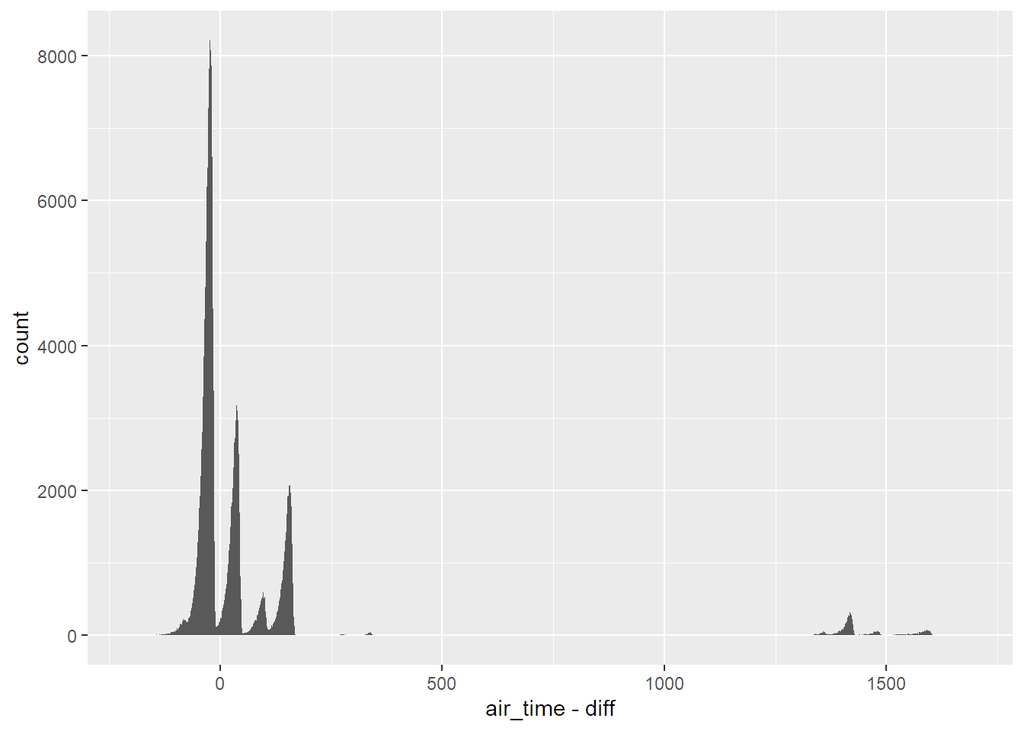

```r
flights_my = mutate(flights, dep_min = ((dep_time%/%100)*60 + dep_time%%100) %% 1440,
                    arr_min = ((arr_time%/%100)*60 + arr_time%%100) %% 1440,
                    diff = arr_min - dep_min)

ggplot(flights_my) + geom_histogram((aes(air_time-diff)), binwidth=1)
```

```r
flights_my %>% filter(air_time-diff!=0)
```

```
## # A tibble: 327,150 x 22
##     year month   day dep_time sched_dep_time dep_delay arr_time sched_arr_time
##    <int> <int> <int>    <int>          <int>     <dbl>    <int>          <int>
##  1  2013     1     1      517            515         2      830            819
##  2  2013     1     1      533            529         4      850            830
##  3  2013     1     1      542            540         2      923            850
##  4  2013     1     1      544            545        -1     1004           1022
##  5  2013     1     1      554            600        -6      812            837
##  6  2013     1     1      554            558        -4      740            728
##  7  2013     1     1      555            600        -5      913            854
##  8  2013     1     1      557            600        -3      709            723
##  9  2013     1     1      557            600        -3      838            846
## 10  2013     1     1      558            600        -2      753            745
## # ... with 327,140 more rows, and 14 more variables: arr_delay <dbl>,
## #   carrier <chr>, flight <int>, tailnum <chr>, origin <chr>, dest <chr>,
## #   air_time <dbl>, distance <dbl>, hour <dbl>, minute <dbl>, time_hour <dttm>,
## #   dep_min <dbl>, arr_min <dbl>, diff <dbl>
```

3. Compare dep_time, sched_dep_time, and dep_delay. How would you expect those three numbers to be related?

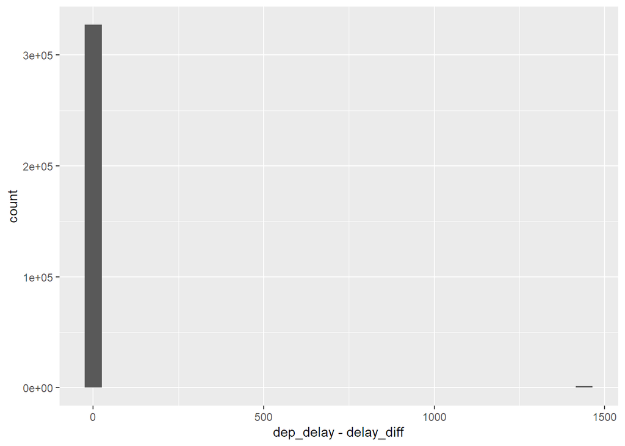

```r
flights_my = mutate(flights, dep_min = ((dep_time%/%100)*60 + dep_time%%100) %% 1440,
                             sched_dep_min = ((sched_dep_time%/%100)*60 + sched_dep_time%%100) %% 1440,
                             delay_diff = dep_min - sched_dep_min )
ggplot(flights_my) +
  geom_histogram(aes(dep_delay-delay_diff))
```

```r
fli = select(flights_my, dep_time, sched_dep_time, dep_min, sched_dep_min, dep_delay, delay_diff)
filter(fli, dep_delay-delay_diff !=0 )
```

```
## # A tibble: 1,236 x 6
##    dep_time sched_dep_time dep_min sched_dep_min dep_delay delay_diff
##       <int>          <int>   <dbl>         <dbl>     <dbl>      <dbl>
##  1      848           1835     528          1115       853       -587
##  2       42           2359      42          1439        43      -1397
##  3      126           2250      86          1370       156      -1284
##  4       32           2359      32          1439        33      -1407
##  5       50           2145      50          1305       185      -1255
##  6      235           2359     155          1439       156      -1284
##  7       25           2359      25          1439        26      -1414
##  8      106           2245      66          1365       141      -1299
##  9       14           2359      14          1439        15      -1425
## 10       37           2230      37          1350       127      -1313
## # ... with 1,226 more rows
```

=> 예정된 출발 시간과 출발 시간의 차이는 dep_delay가 되어야 하지만 같지 않은 경우가 존재한다.  
이는 delay되어 다음날 출발하게 된 경우로 delay time이 맞지 않다.

4. Find the 10 most delayed flights using a ranking function. How do you want to handle ties? Carefully read the documentation for min_rank().
- min_rank, row_number, dense_rank를 통해 내림차순으로 delay 변수 정렬
- slice : 행 선택

```r
flights = mutate(flights, flights_min = min_rank(desc(flights$dep_delay)),
                 flights_row = row_number(desc(flights$dep_delay)),
                 flights_dense = dense_rank(desc(flights$dep_delay)))
flights_rank = filter(flights,
                      flights_min<=10|flights_row<=10|flights_dense<=10) %>%
               arrange(flights_min, flights_row, flights_dense) %>%
               slice(1:10)
flights_rank
```

```
## # A tibble: 10 x 22
##     year month   day dep_time sched_dep_time dep_delay arr_time sched_arr_time
##    <int> <int> <int>    <int>          <int>     <dbl>    <int>          <int>
##  1  2013     1     9      641            900      1301     1242           1530
##  2  2013     6    15     1432           1935      1137     1607           2120
##  3  2013     1    10     1121           1635      1126     1239           1810
##  4  2013     9    20     1139           1845      1014     1457           2210
##  5  2013     7    22      845           1600      1005     1044           1815
##  6  2013     4    10     1100           1900       960     1342           2211
##  7  2013     3    17     2321            810       911      135           1020
##  8  2013     6    27      959           1900       899     1236           2226
##  9  2013     7    22     2257            759       898      121           1026
## 10  2013    12     5      756           1700       896     1058           2020
## # ... with 14 more variables: arr_delay <dbl>, carrier <chr>, flight <int>,
## #   tailnum <chr>, origin <chr>, dest <chr>, air_time <dbl>, distance <dbl>,
## #   hour <dbl>, minute <dbl>, time_hour <dttm>, flights_min <int>,
## #   flights_row <int>, flights_dense <int>
```

```r
top_n(flights, 10, dep_delay)
```

```
## # A tibble: 10 x 22
##     year month   day dep_time sched_dep_time dep_delay arr_time sched_arr_time
##    <int> <int> <int>    <int>          <int>     <dbl>    <int>          <int>
##  1  2013     1     9      641            900      1301     1242           1530
##  2  2013     1    10     1121           1635      1126     1239           1810
##  3  2013    12     5      756           1700       896     1058           2020
##  4  2013     3    17     2321            810       911      135           1020
##  5  2013     4    10     1100           1900       960     1342           2211
##  6  2013     6    15     1432           1935      1137     1607           2120
##  7  2013     6    27      959           1900       899     1236           2226
##  8  2013     7    22      845           1600      1005     1044           1815
##  9  2013     7    22     2257            759       898      121           1026
## 10  2013     9    20     1139           1845      1014     1457           2210
## # ... with 14 more variables: arr_delay <dbl>, carrier <chr>, flight <int>,
## #   tailnum <chr>, origin <chr>, dest <chr>, air_time <dbl>, distance <dbl>,
## #   hour <dbl>, minute <dbl>, time_hour <dttm>, flights_min <int>,
## #   flights_row <int>, flights_dense <int>
```

### 5. Summarise - Group by

- group_by를 통해 각 group별로 summarise 할 수 있다.
- na.rm=TRUE : 결측값을 통계량 계산할 때 포함하지 않는다.

```r
# 전체 delay 평균
summarise(flights, delay = mean(dep_delay, na.rm=TRUE))
```

```
## # A tibble: 1 x 1
##   delay
##   <dbl>
## 1  12.6
```

```r
# day별 delay 평균
by_day = group_by(flights, year, month, day)
summarise(by_day, delay= mean(dep_delay, na.rm=TRUE))
```

```
## # A tibble: 365 x 4
## # Groups:   year, month [12]
##     year month   day delay
##    <int> <int> <int> <dbl>
##  1  2013     1     1 11.5
##  2  2013     1     2 13.9
##  3  2013     1     3 11.0
##  4  2013     1     4  8.95
##  5  2013     1     5  5.73
##  6  2013     1     6  7.15
##  7  2013     1     7  5.42
##  8  2013     1     8  2.55
##  9  2013     1     9  2.28
## 10  2013     1    10  2.84
## # ... with 355 more rows
```

- Combining multiple operations with the pipe - 목적지별 거리와 도착 delay의 관계

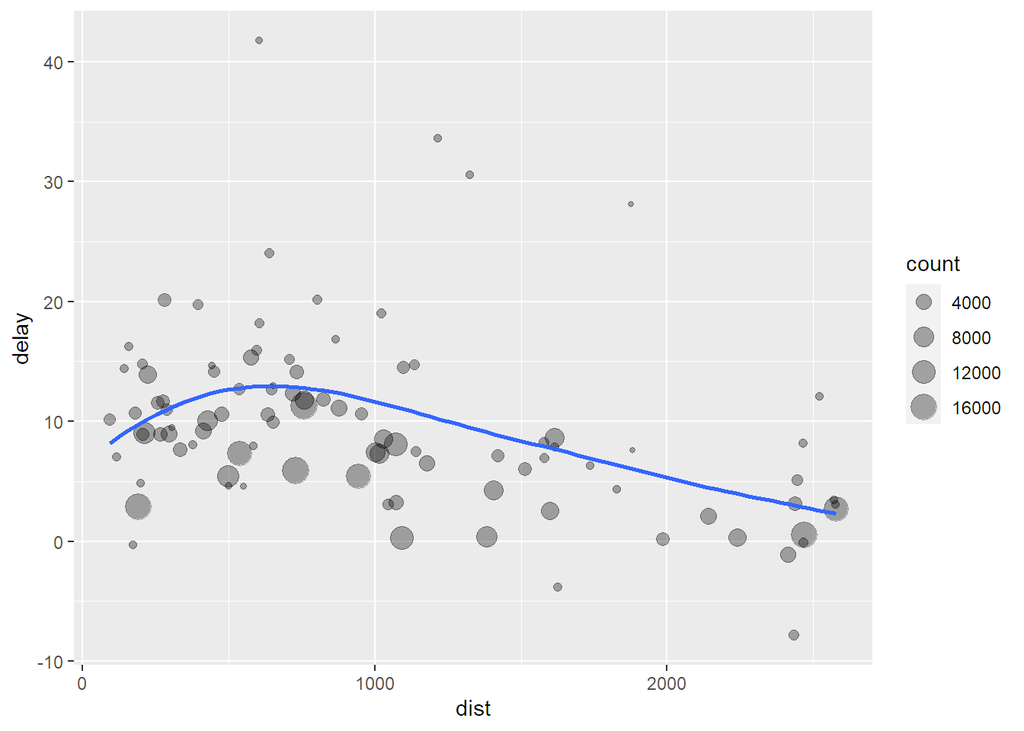

```r
by_dest = group_by(flights, dest)
delay = summarise(by_dest,
                  count = n(),
                  dist = mean(distance, na.rm=TRUE),
                  delay = mean(arr_delay, na.rm=TRUE))
delay = filter(delay, count>20, dest!="HNL")
ggplot(data=delay, mapping=aes(x=dist, y=delay)) +
  geom_point(aes(size=count), alpha=1/3) + geom_smooth(se=FALSE)
```

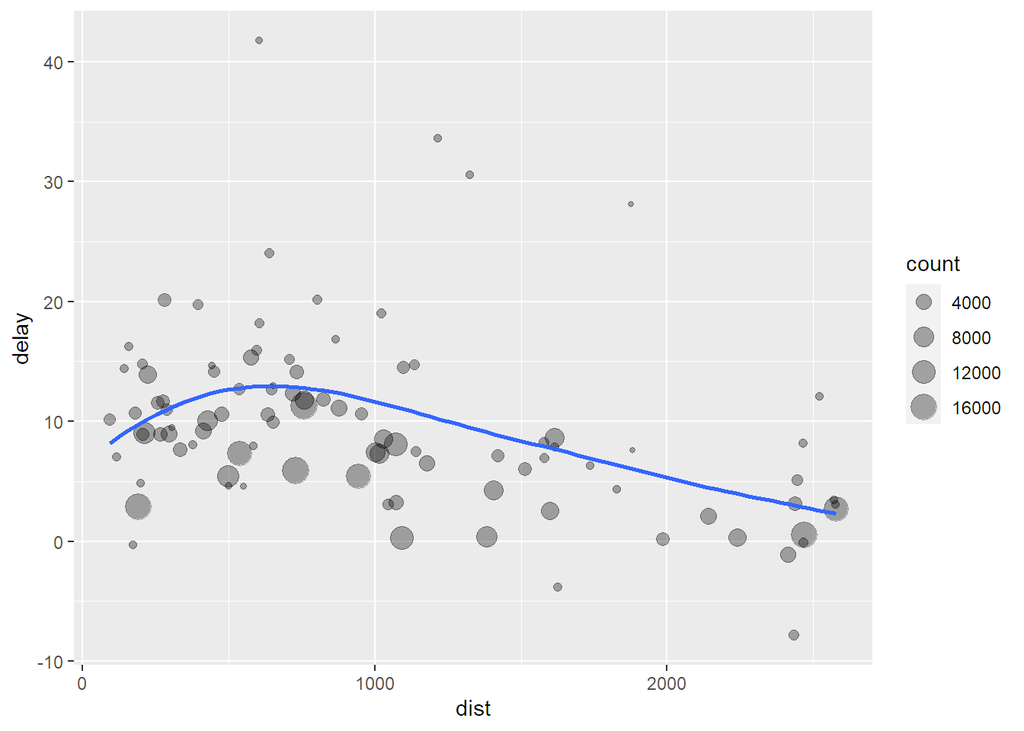

```r
# Use %>%
flights %>%
  group_by(dest) %>%
  summarise(
    count=n(),
    dist=mean(distance, na.rm=TRUE),
    delay=mean(arr_delay, na.rm=TRUE)) %>%
  filter(count>20, dest!="HNL") %>%
  ggplot(mapping=aes(x=dist, y=delay)) +
  geom_point(aes(size=count), alpha=1/3) +
  geom_smooth(se=FALSE)
```

- Missing values
- na.rm=TRUE를 이용하여 결측치 계산하지 않는다.

```r
flights %>%
  group_by(year,month,day) %>%
  summarise(mean=mean(dep_delay, na.rm=TRUE))
```

```
## # A tibble: 365 x 4
## # Groups:   year, month [12]
##     year month   day  mean
##    <int> <int> <int> <dbl>
##  1  2013     1     1 11.5
##  2  2013     1     2 13.9
##  3  2013     1     3 11.0
##  4  2013     1     4  8.95
##  5  2013     1     5  5.73
##  6  2013     1     6  7.15
##  7  2013     1     7  5.42
##  8  2013     1     8  2.55
##  9  2013     1     9  2.28
## 10  2013     1    10  2.84
## # ... with 355 more rows
```

- na데이터를 제거한다.

```r
not_cancelled = flights %>%
  filter(!is.na(dep_delay), !is.na(arr_delay))
not_cancelled %>%
  group_by(year,month,day) %>%
  summarise(mean=mean(dep_delay))
```

```
## # A tibble: 365 x 4
## # Groups:   year, month [12]
##     year month   day  mean
##    <int> <int> <int> <dbl>
##  1  2013     1     1 11.4
##  2  2013     1     2 13.7
##  3  2013     1     3 10.9
##  4  2013     1     4  8.97
##  5  2013     1     5  5.73
##  6  2013     1     6  7.15
##  7  2013     1     7  5.42
##  8  2013     1     8  2.56
##  9  2013     1     9  2.30
## 10  2013     1    10  2.84
## # ... with 355 more rows
```

- Counts
- n() : group내 데이터 개수
- sum(!is.na(x)) : NA가 아닌 데이터 개수

비행기 tailnum에 따른 delay 평균

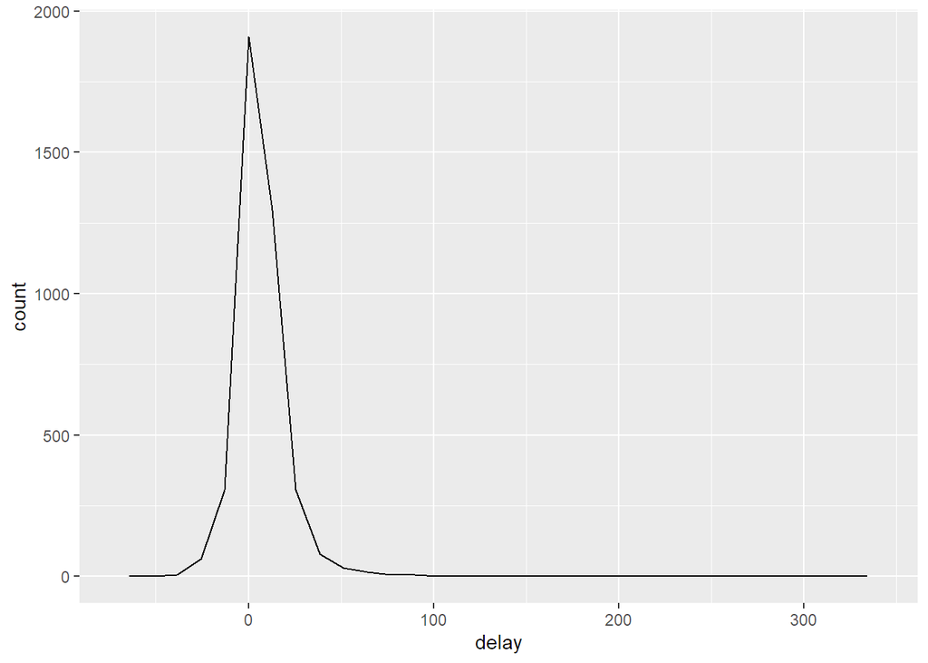

```r
not_cancelled %>%
  group_by(tailnum) %>%
  summarise(delay=mean(arr_delay)) %>%
  ggplot(mapping=aes(x=delay)) +
  geom_freqpoly() #desnsity화
```

delay에 대한 count-> n()을 이용

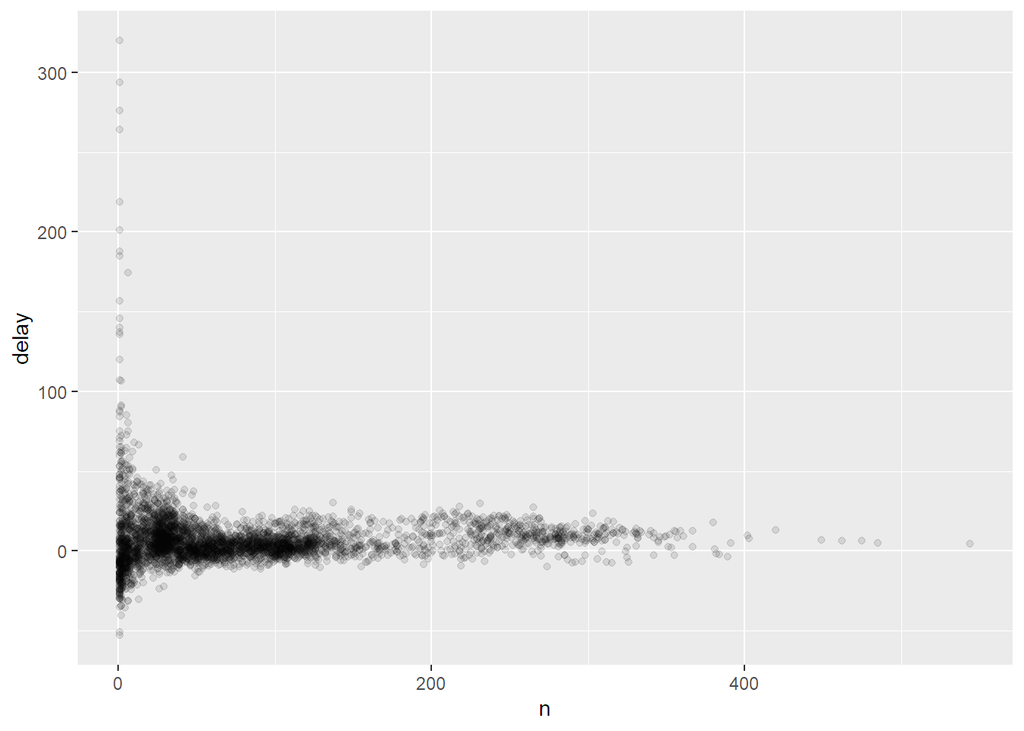

```r
delays = not_cancelled %>%
  group_by(tailnum) %>%
  summarise(delay=mean(arr_delay, na.rm=TRUE), n=n())

ggplot(data=delays, mapping=aes(x=n, y=delay)) + geom_point(alpha=1/10)
```

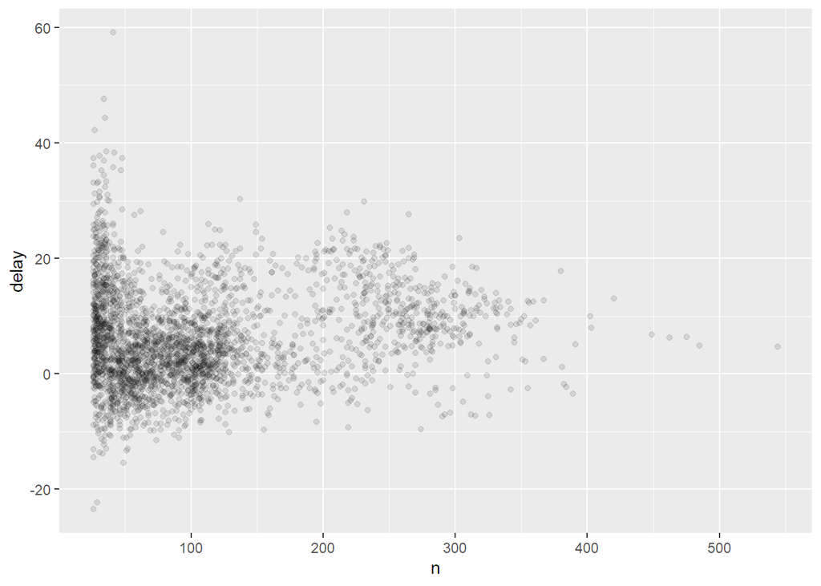

```r
delays %>% filter(n>25) %>%
  ggplot(mapping = aes(x=n, y=delay)) +
  geom_point(alpha=1/10)
```

- Useful summary functions  
  mean : 변수에 대한 평균  
  median : 변수에 대한 중앙값  
  sd : 변수에 대한 표준편차  
  min/max : 변수에 대한 최소값/최대값

```r
not_cancelled %>%
  group_by(year, month, day) %>%
  summarise(
    avg_delay1 = mean(arr_delay),
    avg_delay2 = mean(arr_delay[arr_delay>0]),
    avg_delay3 = median(arr_delay))
```

```
## # A tibble: 365 x 6
## # Groups:   year, month [12]
##     year month   day avg_delay1 avg_delay2 avg_delay3
##    <int> <int> <int>      <dbl>      <dbl>      <dbl>
##  1  2013     1     1     12.7         32.5          3
##  2  2013     1     2     12.7         32.0          4
##  3  2013     1     3      5.73        27.7          1
##  4  2013     1     4     -1.93        28.3         -8
##  5  2013     1     5     -1.53        22.6         -7
##  6  2013     1     6      4.24        24.4         -1
##  7  2013     1     7     -4.95        27.8        -10
##  8  2013     1     8     -3.23        20.8         -7
##  9  2013     1     9     -0.264       25.6         -6
## 10  2013     1    10     -5.90        27.3        -11
## # ... with 355 more rows
```

```r
not_cancelled %>%
  group_by(dest) %>%
  summarise(distance_sd = sd(distance)) %>%
  arrange(desc(distance_sd))
```

```
## # A tibble: 104 x 2
##    dest  distance_sd
##    <chr>       <dbl>
##  1 EGE         10.5
##  2 SAN         10.4
##  3 SFO         10.2
##  4 HNL         10.0
##  5 SEA          9.98
##  6 LAS          9.91
##  7 PDX          9.87
##  8 PHX          9.86
##  9 LAX          9.66
## 10 IND          9.46
## # ... with 94 more rows
```

```r
not_cancelled %>%
  group_by(year, month, day) %>%
  summarise(
    first = min(dep_time),
    last = max(dep_time))
```

```
## # A tibble: 365 x 5
## # Groups:   year, month [12]
##     year month   day first  last
##    <int> <int> <int> <int> <int>
##  1  2013     1     1   517  2356
##  2  2013     1     2    42  2354
##  3  2013     1     3    32  2349
##  4  2013     1     4    25  2358
##  5  2013     1     5    14  2357
##  6  2013     1     6    16  2355
##  7  2013     1     7    49  2359
##  8  2013     1     8   454  2351
##  9  2013     1     9     2  2252
## 10  2013     1    10     3  2320
## # ... with 355 more rows
```

first : 그룹 내에서 첫번째로 위치한 행  
last : 그룹 내에서 마지막으로 위치한 행

```r
not_cancelled %>%
  group_by(year, month, day) %>%
  summarise(
  first_dep = first(dep_time),
  last_dep = last(dep_time))
```

```
## # A tibble: 365 x 5
## # Groups:   year, month [12]
##     year month   day first_dep last_dep
##    <int> <int> <int>     <int>    <int>
##  1  2013     1     1       517     2356
##  2  2013     1     2        42     2354
##  3  2013     1     3        32     2349
##  4  2013     1     4        25     2358
##  5  2013     1     5        14     2357
##  6  2013     1     6        16     2355
##  7  2013     1     7        49     2359
##  8  2013     1     8       454     2351
##  9  2013     1     9         2     2252
## 10  2013     1    10         3     2320
## # ... with 355 more rows
```

range : 범위

```r
not_cancelled %>%
  group_by(year, month, day) %>%
  mutate(r = min_rank(desc(dep_time))) %>%
  filter(r %in% range(r) ) %>% head(10)
```

```
## # A tibble: 10 x 23
## # Groups:   year, month, day [5]
##     year month   day dep_time sched_dep_time dep_delay arr_time sched_arr_time
##    <int> <int> <int>    <int>          <int>     <dbl>    <int>          <int>
##  1  2013     1     1      517            515         2      830            819
##  2  2013     1     1     2356           2359        -3      425            437
##  3  2013     1     2       42           2359        43      518            442
##  4  2013     1     2     2354           2359        -5      413            437
##  5  2013     1     3       32           2359        33      504            442
##  6  2013     1     3     2349           2359       -10      434            445
##  7  2013     1     4       25           2359        26      505            442
##  8  2013     1     4     2358           2359        -1      429            437
##  9  2013     1     4     2358           2359        -1      436            445
## 10  2013     1     5       14           2359        15      503            445
## # ... with 15 more variables: arr_delay <dbl>, carrier <chr>, flight <int>,
## #   tailnum <chr>, origin <chr>, dest <chr>, air_time <dbl>, distance <dbl>,
## #   hour <dbl>, minute <dbl>, time_hour <dttm>, flights_min <int>,
## #   flights_row <int>, flights_dense <int>, r <int>
```

- rank에 대한 범위로 range(r)은 첫번째 순위(1) 또는 마지막 순위를 의미하므로 year/month/day별 첫번째 순위, 마지막순위을 뽑는다.

n_dstinct() : unique한 값에 대한 개수

```r
not_cancelled %>%
  group_by(dest) %>%
  summarise(carriers = n_distinct(carrier)) %>%
  arrange(desc(carriers))
```

```
## # A tibble: 104 x 2
##    dest  carriers
##    <chr>    <int>
##  1 ATL          7
##  2 BOS          7
##  3 CLT          7
##  4 ORD          7
##  5 TPA          7
##  6 AUS          6
##  7 DCA          6
##  8 DTW          6
##  9 IAD          6
## 10 MSP          6
## # ... with 94 more rows
```

count() : 범주별 count  
-> wt 옵션 : 빈도 구할 때 가중치를 적용한다.

```r
# D942DN범주 - 4개
not_cancelled %>%
  count(tailnum)
```

```
## # A tibble: 4,037 x 2
##    tailnum     n
##    <chr>   <int>
##  1 D942DN      4
##  2 N0EGMQ    352
##  3 N10156    145
##  4 N102UW     48
##  5 N103US     46
##  6 N104UW     46
##  7 N10575    269
##  8 N105UW     45
##  9 N107US     41
## 10 N108UW     60
## # ... with 4,027 more rows
```

```r
# 가중치 적용 시, D942DN 3418 -> D942DN일 때, distance의 합과 동일하다.
not_cancelled %>%
  count(tailnum, wt = distance)
```

```
## # A tibble: 4,037 x 2
##    tailnum      n
##    <chr>    <dbl>
##  1 D942DN    3418
##  2 N0EGMQ  239143
##  3 N10156  109664
##  4 N102UW   25722
##  5 N103US   24619
##  6 N104UW   24616
##  7 N10575  139903
##  8 N105UW   23618
##  9 N107US   21677
## 10 N108UW   32070
## # ... with 4,027 more rows
```

```r
filter(not_cancelled, tailnum=="D942DN") %>%
  summarise(sum_dist=sum(distance))
```

```
## # A tibble: 1 x 1
##   sum_dist
##      <dbl>
## 1     3418
```

counts and proportions  
* logical value sum -> count: 조건이 TRUE인 개수  
* logical value mean -> proportion : 조건이 TRUE일 확률

```r
not_cancelled %>%
  group_by(year, month, day) %>%
  summarise(n_early = sum(dep_time < 500))
```

```
## # A tibble: 365 x 4
## # Groups:   year, month [12]
##     year month   day n_early
##    <int> <int> <int>   <int>
##  1  2013     1     1       0
##  2  2013     1     2       3
##  3  2013     1     3       4
##  4  2013     1     4       3
##  5  2013     1     5       3
##  6  2013     1     6       2
##  7  2013     1     7       2
##  8  2013     1     8       1
##  9  2013     1     9       3
## 10  2013     1    10       3
## # ... with 355 more rows
```

```r
not_cancelled %>%
  group_by(year, month, day) %>%
  summarise(hour_prop = mean(arr_delay > 60))
```

```
## # A tibble: 365 x 4
## # Groups:   year, month [12]
##     year month   day hour_prop
##    <int> <int> <int>     <dbl>
##  1  2013     1     1    0.0722
##  2  2013     1     2    0.0851
##  3  2013     1     3    0.0567
##  4  2013     1     4    0.0396
##  5  2013     1     5    0.0349
##  6  2013     1     6    0.0470
##  7  2013     1     7    0.0333
##  8  2013     1     8    0.0213
##  9  2013     1     9    0.0202
## 10  2013     1    10    0.0183
## # ... with 355 more rows
```

- Grouping by multiple variables 여러 변수를 기준으로 그룹화하였을 때, summarise 반복시 한 수준의 그룹씩 벗겨진다.

```r
daily = group_by(flights, year, month, day)
(per_day = summarise(daily, flights=n()))
```

```
## # A tibble: 365 x 4
## # Groups:   year, month [12]
##     year month   day flights
##    <int> <int> <int>   <int>
##  1  2013     1     1     842
##  2  2013     1     2     943
##  3  2013     1     3     914
##  4  2013     1     4     915
##  5  2013     1     5     720
##  6  2013     1     6     832
##  7  2013     1     7     933
##  8  2013     1     8     899
##  9  2013     1     9     902
## 10  2013     1    10     932
## # ... with 355 more rows
```

```r
(per_month = summarise(per_day, flights=sum(flights)))
```

```
## # A tibble: 12 x 3
## # Groups:   year [1]
##     year month flights
##    <int> <int>   <int>
##  1  2013     1   27004
##  2  2013     2   24951
##  3  2013     3   28834
##  4  2013     4   28330
##  5  2013     5   28796
##  6  2013     6   28243
##  7  2013     7   29425
##  8  2013     8   29327
##  9  2013     9   27574
## 10  2013    10   28889
## 11  2013    11   27268
## 12  2013    12   28135
```

```r
(per_year = summarise(per_month, flights=sum(flights)))
```

```
## # A tibble: 1 x 2
##    year flights
##   <int>   <int>
## 1  2013  336776
```

```r
#ungroup -> group화 모두 풀린다.
daily %>%
  ungroup() %>%
  summarise(flights=n())
```

```
## # A tibble: 1 x 1
##   flights
##     <int>
## 1  336776
```

### Summarise - My turn

1. Come up with another approach that will give you the same output as not_cancelled %>% count(dest) and not_cancelled %>% count(tailnum, wt = distance) (without using count()).

```r
not_cancelled = flights %>% filter(!is.na(dep_delay), !is.na(arr_delay))
```

1-1) not_cancelled %>% count(dest)

```r
not_cancelled %>%
  group_by(dest) %>%
  summarise(n())
```

```
## # A tibble: 104 x 2
##    dest  `n()`
##    <chr> <int>
##  1 ABQ     254
##  2 ACK     264
##  3 ALB     418
##  4 ANC       8
##  5 ATL   16837
##  6 AUS    2411
##  7 AVL     261
##  8 BDL     412
##  9 BGR     358
## 10 BHM     269
## # ... with 94 more rows
```

- group_by를 이용하여 dest별 몇 개의 데이터가 있는지 계산한다.

1-2) not_cancelled %>% count(tailnum, wt=distance)

```r
not_cancelled %>%
  group_by(tailnum) %>%
  summarise(sum(distance))
```

```
## # A tibble: 4,037 x 2
##    tailnum `sum(distance)`
##    <chr>             <dbl>
##  1 D942DN             3418
##  2 N0EGMQ           239143
##  3 N10156           109664
##  4 N102UW            25722
##  5 N103US            24619
##  6 N104UW            24616
##  7 N10575           139903
##  8 N105UW            23618
##  9 N107US            21677
## 10 N108UW            32070
## # ... with 4,027 more rows
```

- distance 가중치를 주어 count하므로 tailnum별 distance를 모두 더한다.

2) Look at the number of canceled flights per day. Is there a pattern? Is the proportion of canceled flights related to the average delay?

```r
(cancel = flights %>% group_by(year,month, day) %>%
  summarise(cancel_n = sum(is.na(dep_delay)|is.na(arr_delay)),
            cancel_prop = mean(is.na(dep_delay)|is.na(arr_delay)),
            average_delay = sum(dep_delay>0|arr_delay>0, na.rm=TRUE)))
```

```
## # A tibble: 365 x 6
## # Groups:   year, month [12]
##     year month   day cancel_n cancel_prop average_delay
##    <int> <int> <int>    <int>       <dbl>         <int>
##  1  2013     1     1       11     0.0131            539
##  2  2013     1     2       15     0.0159            635
##  3  2013     1     3       14     0.0153            575
##  4  2013     1     4        7     0.00765           450
##  5  2013     1     5        3     0.00417           341
##  6  2013     1     6        3     0.00361           480
##  7  2013     1     7        3     0.00322           378
##  8  2013     1     8        7     0.00779           370
##  9  2013     1     9        9     0.00998           349
## 10  2013     1    10        3     0.00322           286
## # ... with 355 more rows
```

- cancel_n = day별 취소 수
- cancel_prop = day별 취소 확률
- average_delay = day별 평균 delay 횟수

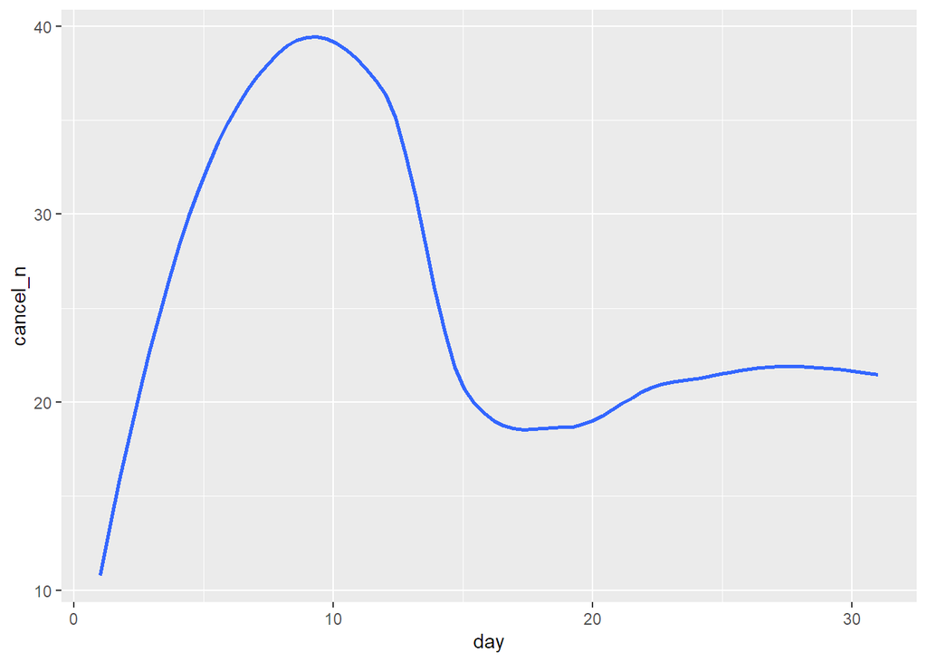

```r
cancel %>% ggplot(aes(x=day,y=cancel_n)) +
  geom_smooth(se=FALSE)
```

- Day별 취소 수 - 대체로 8~12일에 취소 수가 가장 많다.

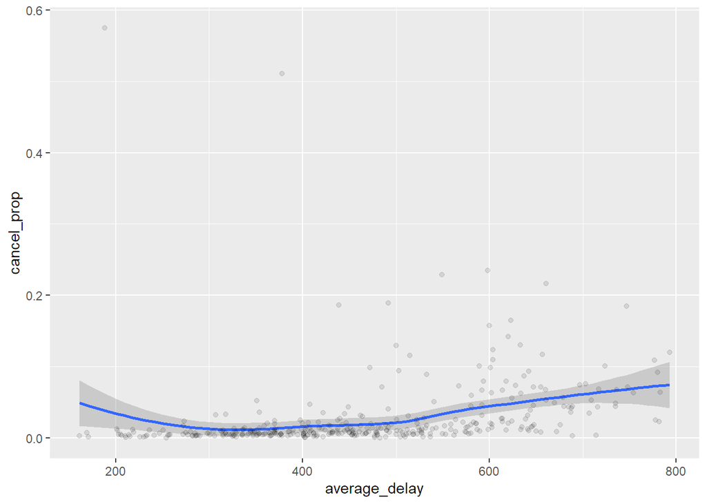

```r
cancel %>% ggplot(aes(x=average_delay, y=cancel_prop)) +
  geom_smooth() + geom_point(alpha=0.1)
```

- 평균 delday수와 cancel 확률 관계 - delay 수가 많을수록 cancel될 확률이 높다.
3. Which carrier has the worst delays? Challenge: can you disentangle the effects of bad airports vs. bad carriers? Why/why not? (Hint: think about flights %>% group_by(carrier, dest) %>% summarise(n()))

```r
(car =flights %>% group_by(carrier) %>%
  summarise(delay_n=sum(arr_delay>0, na.rm=TRUE),
            delay_prop=mean(arr_delay>0, na.rm=TRUE)) %>%
   arrange(desc(delay_n)))
```

```
## # A tibble: 16 x 3
##    carrier delay_n delay_prop
##    <chr>     <int>      <dbl>
##  1 EV        24484      0.479
##  2 B6        23609      0.437
##  3 UA        22222      0.385
##  4 DL        16413      0.344
##  5 MQ        11693      0.467
##  6 AA        10706      0.335
##  7 US         7349      0.371
##  8 9E         6637      0.384
##  9 WN         5304      0.440
## 10 FL         1895      0.597
## 11 VX         1746      0.341
## 12 F9          392      0.576
## 13 YV          258      0.474
## 14 AS          189      0.267
## 15 HA           97      0.284
## 16 OO           10      0.345
```

- EV carrier가 가장 delay 횟수가 많았다.

```r
(des = flights %>%
  group_by(carrier, dest, origin) %>%
  summarise(n = n(),
        dest_delay_n = sum(arr_delay>0, na.rm=TRUE),
        dest_delay_prop = mean(arr_delay>0, na.rm=TRUE)) %>%
  arrange(desc(dest_delay_n)))
```

```
## # A tibble: 439 x 6
## # Groups:   carrier, dest [314]
##    carrier dest  origin     n dest_delay_n dest_delay_prop
##    <chr>   <chr> <chr>  <int>        <int>           <dbl>
##  1 DL      ATL   LGA     5544         2174           0.398
##  2 US      DCA   LGA     4716         1877           0.420
##  3 UA      SFO   EWR     4344         1762           0.411
##  4 UA      IAH   EWR     3973         1675           0.427
##  5 AA      ORD   LGA     5694         1658           0.302
##  6 UA      LAX   EWR     3764         1604           0.430
##  7 B6      MCO   JFK     3304         1582           0.482
##  8 AA      DFW   LGA     4836         1576           0.338
##  9 B6      FLL   JFK     2989         1463           0.495
## 10 MQ      RDU   LGA     3334         1419           0.452
## # ... with 429 more rows
```

- origin-destination을 고려하였을 때 delay횟수가 가장 많은 경우는 DL carrier가 LGA에서 ATL로 갈 때로 carrier만을 고려했을 때와는 다른 결과이다. 이에 따라 destination을 고려하여 구한 delday가 될 확률과 carrier만을 고려했을 때의 delay가 될 확률을 비교해보도록 하여 두 영향을 구분할 수 있는지 확인해본다.

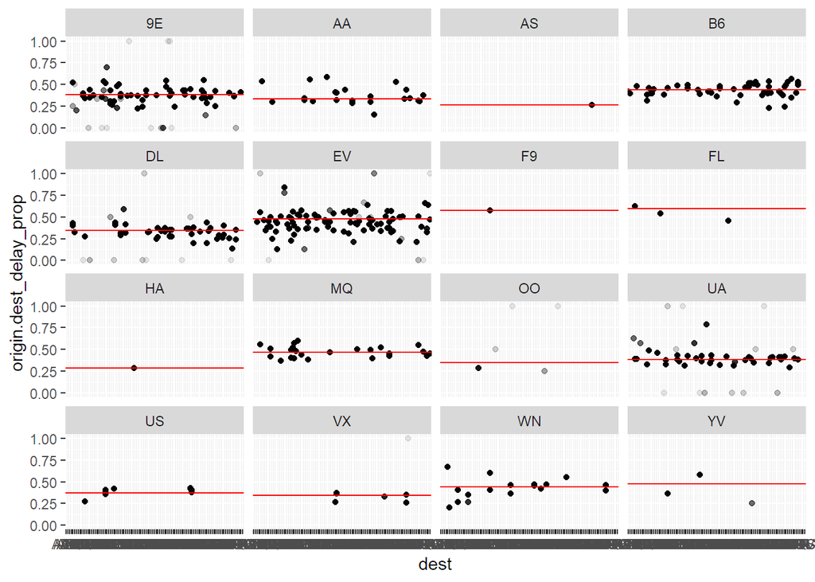

```r
vs = flights %>%
  group_by(carrier) %>%
  mutate(delay_prop=mean(arr_delay>0, na.rm=TRUE)) %>% ungroup() %>%
  group_by(carrier,origin,dest) %>%
  mutate(origin.dest_delay_prop = mean(arr_delay>0, na.rm=TRUE))

vs %>%
  ggplot() +
  geom_point(mapping=aes(x=dest, y=origin.dest_delay_prop) ,alpha=0.1)  +
  geom_hline(aes(yintercept=delay_prop),col="red") + facet_wrap(~carrier)
```

- 위의 그래프를 보면 9E, DL, EV, UA carrier의 경우 origin-destination에 따라 delay가 될 확률이 carrier만 고려하였을 때 delay가 될 확률보다 높거나 낮은 경우가 있으므로 어느 정도 구분은 가능하나 나머지느 대체로 carrie만 고려하였을 때의 확률과 유사한 것으로 보여 구분이 어려워 보인다.
4. Counts the number of flights to a destination and sorts them from highest to lowest.

```r
flights %>% group_by(dest) %>%
  summarise(n=n()) %>% arrange(desc(n))
```

```
## # A tibble: 105 x 2
##    dest      n
##    <chr> <int>
##  1 ORD   17283
##  2 ATL   17215
##  3 LAX   16174
##  4 BOS   15508
##  5 MCO   14082
##  6 CLT   14064
##  7 SFO   13331
##  8 FLL   12055
##  9 MIA   11728
## 10 DCA    9705
## # ... with 95 more rows
```

- ORD에 17283개가 가장 많이 비행기가 도착하였고 LEX와 LGA는 1개로 가장 적게 비행기가 도착하였다.

### Grouped mutates and filters

-> group_by를 이용하여 mutate, filter할 수 있다.

```r
#각 group에서 worst members
flights_sml %>%
  group_by(year,month,day) %>%
  filter(rank(desc(arr_delay)) < 10)
```

```
## # A tibble: 3,306 x 7
## # Groups:   year, month, day [365]
##     year month   day dep_delay arr_delay distance air_time
##    <int> <int> <int>     <dbl>     <dbl>    <dbl>    <dbl>
##  1  2013     1     1       853       851      184       41
##  2  2013     1     1       290       338     1134      213
##  3  2013     1     1       260       263      266       46
##  4  2013     1     1       157       174      213       60
##  5  2013     1     1       216       222      708      121
##  6  2013     1     1       255       250      589      115
##  7  2013     1     1       285       246     1085      146
##  8  2013     1     1       192       191      199       44
##  9  2013     1     1       379       456     1092      222
## 10  2013     1     2       224       207      550       94
## # ... with 3,296 more rows
```

```r
#dest별 delay 수가 365보다 큰 경우
(popular_dests = flights %>%
  group_by(dest) %>%
  filter(n() > 365))
```

```
## # A tibble: 332,577 x 22
## # Groups:   dest [77]
##     year month   day dep_time sched_dep_time dep_delay arr_time sched_arr_time
##    <int> <int> <int>    <int>          <int>     <dbl>    <int>          <int>
##  1  2013     1     1      517            515         2      830            819
##  2  2013     1     1      533            529         4      850            830
##  3  2013     1     1      542            540         2      923            850
##  4  2013     1     1      544            545        -1     1004           1022
##  5  2013     1     1      554            600        -6      812            837
##  6  2013     1     1      554            558        -4      740            728
##  7  2013     1     1      555            600        -5      913            854
##  8  2013     1     1      557            600        -3      709            723
##  9  2013     1     1      557            600        -3      838            846
## 10  2013     1     1      558            600        -2      753            745
## # ... with 332,567 more rows, and 14 more variables: arr_delay <dbl>,
## #   carrier <chr>, flight <int>, tailnum <chr>, origin <chr>, dest <chr>,
## #   air_time <dbl>, distance <dbl>, hour <dbl>, minute <dbl>, time_hour <dttm>,
## #   flights_min <int>, flights_row <int>, flights_dense <int>
```

```r
#dest별 delay 비중 계산
popular_dests %>%
  filter(arr_delay > 0) %>%
  mutate(prop_delay=arr_delay/sum(arr_delay)) %>%
  select(year:day, dest, arr_delay, prop_delay)
```

```
## # A tibble: 131,106 x 6
## # Groups:   dest [77]
##     year month   day dest  arr_delay prop_delay
##    <int> <int> <int> <chr>     <dbl>      <dbl>
##  1  2013     1     1 IAH          11  0.000111
##  2  2013     1     1 IAH          20  0.000201
##  3  2013     1     1 MIA          33  0.000235
##  4  2013     1     1 ORD          12  0.0000424
##  5  2013     1     1 FLL          19  0.0000938
##  6  2013     1     1 ORD           8  0.0000283
##  7  2013     1     1 LAX           7  0.0000344
##  8  2013     1     1 DFW          31  0.000282
##  9  2013     1     1 ATL          12  0.0000400
## 10  2013     1     1 DTW          16  0.000116
## # ... with 131,096 more rows
```

#### Practice myself

| 계산 | group화하지 않았을 경우 | group화한 경우 |
| --- | --- | --- |
| 평균,lag,lead,cum- | 전체 계산 | group별 계산 |
| 덧셈,나눗셈,log화 | 각각 계산 | group별 계산하지만 결과 동일 |

```r
tibble(x=1:9, group=rep(c("a","b","c"), each=3)) %>%
  mutate(x_mean = mean(x)) %>%
  group_by(group) %>%
  mutate(x_mean_2 = mean(x))
```

```
## # A tibble: 9 x 4
## # Groups:   group [3]
##       x group x_mean x_mean_2
##   <int> <chr>  <dbl>    <dbl>
## 1     1 a          5        2
## 2     2 a          5        2
## 3     3 a          5        2
## 4     4 b          5        5
## 5     5 b          5        5
## 6     6 b          5        5
## 7     7 c          5        8
## 8     8 c          5        8
## 9     9 c          5        8
```

```r
tibble(x=1:9, group=rep(c("a","b","c"), each=3)) %>%
  mutate(y = x+2) %>%
  group_by(group) %>%
  mutate(z = x+2)
```

```
## # A tibble: 9 x 4
## # Groups:   group [3]
##       x group     y     z
##   <int> <chr> <dbl> <dbl>
## 1     1 a         3     3
## 2     2 a         4     4
## 3     3 a         5     5
## 4     4 b         6     6
## 5     5 b         7     7
## 6     6 b         8     8
## 7     7 c         9     9
## 8     8 c        10    10
## 9     9 c        11    11
```

```r
tibble(x = 1:9,
       group = rep(c("a", "b", "c"), each = 3)) %>%
  mutate(y = x %% 2) %>%
  group_by(group) %>%
  mutate(z = x %% 2)
```

```
## # A tibble: 9 x 4
## # Groups:   group [3]
##       x group     y     z
##   <int> <chr> <dbl> <dbl>
## 1     1 a         1     1
## 2     2 a         0     0
## 3     3 a         1     1
## 4     4 b         0     0
## 5     5 b         1     1
## 6     6 b         0     0
## 7     7 c         1     1
## 8     8 c         0     0
## 9     9 c         1     1
```

```r
tibble(x = 1:9,
       group = rep(c("a", "b", "c"), each = 3)) %>%
  mutate(y = log(x)) %>%
  group_by(group) %>%
  mutate(z = log(x))
```

```
## # A tibble: 9 x 4
## # Groups:   group [3]
##       x group     y     z
##   <int> <chr> <dbl> <dbl>
## 1     1 a     0     0
## 2     2 a     0.693 0.693
## 3     3 a     1.10  1.10
## 4     4 b     1.39  1.39
## 5     5 b     1.61  1.61
## 6     6 b     1.79  1.79
## 7     7 c     1.95  1.95
## 8     8 c     2.08  2.08
## 9     9 c     2.20  2.20
```

- lag(x) : 앞 순서의 x값
- lead(x) : 뒤 순서의 x값

```r
tibble(x = 1:9,
       group = rep(c("a", "b", "c"), each = 3)) %>%
  mutate(lag_x_notgroup = lag(x), lead_x_notgroup = lead(x)) %>%
  group_by(group) %>%
  mutate(lag_x = lag(x), lead_x = lead(x))
```

```
## # A tibble: 9 x 6
## # Groups:   group [3]
##       x group lag_x_notgroup lead_x_notgroup lag_x lead_x
##   <int> <chr>          <int>           <int> <int>  <int>
## 1     1 a                 NA               2    NA      2
## 2     2 a                  1               3     1      3
## 3     3 a                  2               4     2     NA
## 4     4 b                  3               5    NA      5
## 5     5 b                  4               6     4      6
## 6     6 b                  5               7     5     NA
## 7     7 c                  6               8    NA      8
## 8     8 c                  7               9     7      9
## 9     9 c                  8              NA     8     NA
```

- cumsum : 누적합, cummin: 누적최소값, cummax: 누적최대값, cummean: 누적평균값

```r
tibble(x = 1:9,
       group = rep(c("a", "b", "c"), each = 3)) %>%
  mutate(x_cumsum = cumsum(x)) %>%
  group_by(group) %>%
  mutate(x_cumsum_2 = cumsum(x))
```

```
## # A tibble: 9 x 4
## # Groups:   group [3]
##       x group x_cumsum x_cumsum_2
##   <int> <chr>    <int>      <int>
## 1     1 a            1          1
## 2     2 a            3          3
## 3     3 a            6          6
## 4     4 b           10          4
## 5     5 b           15          9
## 6     6 b           21         15
## 7     7 c           28          7
## 8     8 c           36         15
## 9     9 c           45         24
```

- logical comparison(<, <=,>, >=, !=, and ==)은 group_by에 영향을 받지 않는다.

```r
tibble(x = 1:9,
       y = 9:1,
       group = rep(c("a", "b", "c"), each = 3)) %>%
  mutate(x_lte_y = x <= y) %>%
  group_by(group) %>%
  mutate(x_lte_y_2 = x <= y)
```

```
## # A tibble: 9 x 5
## # Groups:   group [3]
##       x     y group x_lte_y x_lte_y_2
##   <int> <int> <chr> <lgl>   <lgl>
## 1     1     9 a     TRUE    TRUE
## 2     2     8 a     TRUE    TRUE
## 3     3     7 a     TRUE    TRUE
## 4     4     6 b     TRUE    TRUE
## 5     5     5 b     TRUE    TRUE
## 6     6     4 b     FALSE   FALSE
## 7     7     3 c     FALSE   FALSE
## 8     8     2 c     FALSE   FALSE
## 9     9     1 c     FALSE   FALSE
```

- rank(순위 작성)는 전체순위와 group별 순위 따로 작성된다.

```r
tibble(x = 1:9,
       group = rep(c("a", "b", "c"), each = 3)) %>%
  mutate(rnk = min_rank(x)) %>%
  group_by(group) %>%
  mutate(rnk2 = min_rank(x))
```

```
## # A tibble: 9 x 4
## # Groups:   group [3]
##       x group   rnk  rnk2
##   <int> <chr> <int> <int>
## 1     1 a         1     1
## 2     2 a         2     2
## 3     3 a         3     3
## 4     4 b         4     1
## 5     5 b         5     2
## 6     6 b         6     3
## 7     7 c         7     1
## 8     8 c         8     2
## 9     9 c         9     3
```

- arrange(정렬)은 group을 무시하고 기준 변수로 정렬한다.

```r
tibble(x = runif(9),
       group = rep(c("a", "b", "c"), each = 3)) %>%
  group_by(group) %>%
  arrange(x)
```

```
## # A tibble: 9 x 2
## # Groups:   group [3]
##        x group
##    <dbl> <chr>
## 1 0.0713 b
## 2 0.193  c
## 3 0.296  c
## 4 0.427  a
## 5 0.440  a
## 6 0.579  a
## 7 0.766  c
## 8 0.901  b
## 9 0.907  b
```

```r
tibble(group = rep(c("a", "b", "c"), each = 3),
       x = runif(9)) %>%
  group_by(group) %>%
  arrange(x) %>%
  mutate(lag_x = lag(x))
```

```
## # A tibble: 9 x 3
## # Groups:   group [3]
##   group      x   lag_x
##   <chr>  <dbl>   <dbl>
## 1 b     0.0870 NA
## 2 a     0.183  NA
## 3 b     0.237   0.0870
## 4 b     0.342   0.237
## 5 a     0.428   0.183
## 6 c     0.485  NA
## 7 c     0.627   0.485
## 8 c     0.864   0.627
## 9 a     0.878   0.428
```

#### Grouped mutates and filters - My turn

1. Which plane (tailnum) has the worst on-time record?  
   1-1) proportion of flights not delayed or canceled, and

```r
flights %>%
  filter(!is.na(tailnum)) %>%
  group_by(tailnum) %>%
  mutate(prop = mean(arr_delay <=0 & (!is.na(arr_delay)|!is.na(dep_delay))), na.rm=TRUE) %>%
  select(tailnum, prop) %>%  arrange(prop)
```

```
## # A tibble: 334,264 x 2
## # Groups:   tailnum [4,043]
##    tailnum  prop
##    <chr>   <dbl>
##  1 N26906      0
##  2 N801AW      0
##  3 N383SW      0
##  4 N835MH      0
##  5 N17627      0
##  6 N624AW      0
##  7 N953FR      0
##  8 N589AS      0
##  9 N965DN      0
## 10 N635SW      0
## # ... with 334,254 more rows
```

- prop이 낮을수록 delay나 cancel이 많은 나쁜 plane이다.

1-2) mean arrival delay.

```r
flights %>% group_by(tailnum) %>%
  mutate(arr_delay_mean = mean(arr_delay>0, na.rm=TRUE)) %>%
  select(tailnum, arr_delay_mean) %>% arrange(desc(arr_delay_mean))
```

```
## # A tibble: 336,776 x 2
## # Groups:   tailnum [4,044]
##    tailnum arr_delay_mean
##    <chr>            <dbl>
##  1 N26906               1
##  2 N801AW               1
##  3 N383SW               1
##  4 N835MH               1
##  5 N17627               1
##  6 N624AW               1
##  7 N953FR               1
##  8 N589AS               1
##  9 N965DN               1
## 10 N635SW               1
## # ... with 336,766 more rows
```

- arr_delay_mean이 더 높을수록 delay가 많은 나쁜 plane이다.
2. What time of day should you fly if you want to avoid delays as much as possible? (Hint: The earlier the flight is scheduled, the lower its expected delay.)

```r
flights = flights %>%
  mutate(sched_dep_min = ((sched_dep_time%/%100)*60 + sched_dep_time%%100)%%1440,)

(not = flights %>%
  group_by(sched_dep_min) %>%
  mutate(not_delay = sum(arr_delay<=0, na.rm=TRUE),
         n = n(),
         not_prop = not_delay/n) %>%
  select(sched_dep_min, not_delay, n, not_prop) %>%
  arrange(desc(not_prop)))
```

```
## # A tibble: 336,776 x 4
## # Groups:   sched_dep_min [1,021]
##    sched_dep_min not_delay     n not_prop
##            <dbl>     <int> <int>    <dbl>
##  1           320         7     7        1
##  2           320         7     7        1
##  3           320         7     7        1
##  4           320         7     7        1
##  5           320         7     7        1
##  6           328         1     1        1
##  7           357         3     3        1
##  8          1321         1     1        1
##  9           301         1     1        1
## 10           355         2     2        1
## # ... with 336,766 more rows
```

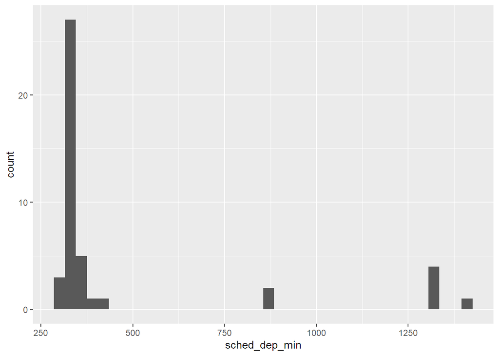

```r
not %>% filter(not_prop==1) %>%
  ggplot(aes(x=sched_dep_min)) +
  geom_histogram(xlim=c(0,1440),binwidth=30)
```

- 약 300-330 minute, 즉 오전 5시-5시30분에 출발 하는 것이 가장 delay를 피할 수 있다.

3-1) For each destination, compute the total minutes of delay.

```r
dest = flights %>%
  filter(arr_delay>0) %>%
  group_by(dest) %>%
  mutate(total = sum(arr_delay)) %>%
  select(dest,flight,arr_delay, total)

dest %>% arrange(total)
```

```
## # A tibble: 133,004 x 4
## # Groups:   dest [103]
##    dest  flight arr_delay total
##    <chr>  <int>     <dbl> <dbl>
##  1 PSP       55         1    36
##  2 PSP       55         1    36
##  3 PSP       55         4    36
##  4 PSP       55         8    36
##  5 PSP       55        17    36
##  6 PSP       55         5    36
##  7 ANC      887         1    62
##  8 ANC      887         2    62
##  9 ANC      887        10    62
## 10 ANC      887        10    62
## # ... with 132,994 more rows
```

```r
dest %>% arrange(desc(total))
```

```
## # A tibble: 133,004 x 4
## # Groups:   dest [103]
##    dest  flight arr_delay  total
##    <chr>  <int>     <dbl>  <dbl>
##  1 ATL     4650        12 300299
##  2 ATL     1547         5 300299
##  3 ATL      346        17 300299
##  4 ATL     4654         6 300299
##  5 ATL      347         2 300299
##  6 ATL     4876        11 300299
##  7 ATL     4658        22 300299
##  8 ATL     1947         1 300299
##  9 ATL     3850        24 300299
## 10 ATL      781         4 300299
## # ... with 132,994 more rows
```

- total = 각 목적지에 대한 총 delay 시간
- 가장 delay가 짧은 곳 = PSP
- 가장 delay가 많은 곳 = ATL

3-2) For each flight, compute the proportion of the total delay for its destination.

```r
dest %>%
  group_by(flight) %>%
  mutate(prop = arr_delay/total) %>%
  arrange(prop)
```

```
## # A tibble: 133,004 x 5
## # Groups:   flight [3,432]
##    dest  flight arr_delay  total       prop
##    <chr>  <int>     <dbl>  <dbl>      <dbl>
##  1 ATL     1947         1 300299 0.00000333
##  2 ATL     2043         1 300299 0.00000333
##  3 ATL     1743         1 300299 0.00000333
##  4 ATL      349         1 300299 0.00000333
##  5 ATL     1647         1 300299 0.00000333
##  6 ATL      781         1 300299 0.00000333
##  7 ATL     1499         1 300299 0.00000333
##  8 ATL     4662         1 300299 0.00000333
##  9 ATL     4669         1 300299 0.00000333
## 10 ATL      847         1 300299 0.00000333
## # ... with 132,994 more rows
```

- prop = 항공편의 목적지에 대한 delay 비율
4. Delays are typically temporally correlated: even once the problem that caused the initial delay has been resolved, later flights are delayed to allow earlier flights to leave. Draw a the scatter plot between mean of dep_delay of flights and the dep_delay of the immediately preceding flight. Hint 1: Using lag(), explore how the delay of a flight is related to the delay of the immediately preceding flight. Use lag() to get the info of dep_delay of a previous flight in the same origin. Before using lag(), the data should be ordered by origin, month, day, dep_time. Hint 2: group by the dep_delay of the immediately preceding flight and find the mean of dep_delay of current flights.

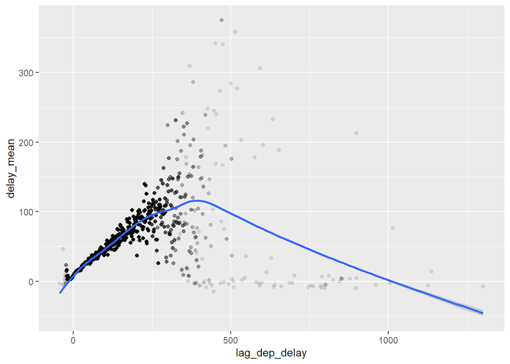

```r
corr = flights %>%
  select(origin, year, month, day, dep_time, dep_delay) %>%
  arrange(origin,year, month, day, dep_time) %>%
  group_by(origin) %>%
  mutate(lag_dep_delay = lag(dep_delay))

corr %>%
  group_by(lag_dep_delay) %>%
  mutate(delay_mean = mean(dep_delay, na.rm=TRUE)) %>%
  ggplot(mapping=aes(x=lag_dep_delay,y=delay_mean)) +
  geom_point(alpha=0.1) + geom_smooth()
```

5) Look at each destination. Can you find flights that are suspiciously fast? (i.e. flights that represent a potential data entry error). Compute the air time of a flight relative to the shortest flight to that destination. Which flights were most delayed in the air? Hint: Standardize air time.

```r
flights %>%
  arrange(air_time) %>%
  select(year,month,day,air_time, origin, dest, carrier, everything())
```

```
## # A tibble: 336,776 x 23
##     year month   day air_time origin dest  carrier dep_time sched_dep_time
##    <int> <int> <int>    <dbl> <chr>  <chr> <chr>      <int>          <int>
##  1  2013     1    16       20 EWR    BDL   EV          1355           1315
##  2  2013     4    13       20 EWR    BDL   EV           537            527
##  3  2013    12     6       21 EWR    BDL   EV           922            851
##  4  2013     2     3       21 EWR    PHL   EV          2153           2129
##  5  2013     2     5       21 EWR    BDL   EV          1303           1315
##  6  2013     2    12       21 EWR    PHL   EV          2123           2130
##  7  2013     3     2       21 LGA    BOS   US          1450           1500
##  8  2013     3     8       21 JFK    PHL   9E          2026           1935
##  9  2013     3    18       21 EWR    BDL   EV          1456           1329
## 10  2013     3    19       21 EWR    BDL   EV          2226           2145
## # ... with 336,766 more rows, and 14 more variables: dep_delay <dbl>,
## #   arr_time <int>, sched_arr_time <int>, arr_delay <dbl>, flight <int>,
## #   tailnum <chr>, distance <dbl>, hour <dbl>, minute <dbl>, time_hour <dttm>,
## #   flights_min <int>, flights_row <int>, flights_dense <int>,
## #   sched_dep_min <dbl>
```

- 가장 빠른 비행은 20분이다.

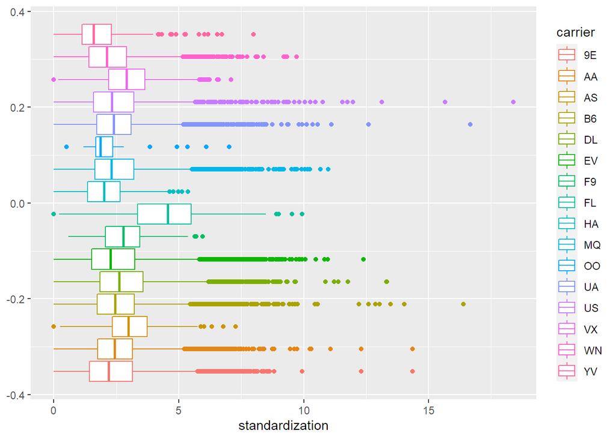

```r
delay = flights %>%
  group_by(origin, dest) %>%
  mutate(min_air_time = min(air_time, na.rm=TRUE),
         delay_in_air = air_time - min_air_time,
         sd_air = sd(air_time, na.rm=TRUE),
         standardization = delay_in_air/sd_air) %>%
  select(air_time, origin, dest, carrier, min_air_time,
         delay_in_air, sd_air, standardization, everything()) %>%
  arrange(origin,dest)

delay %>%
  ggplot(aes(standardization)) +
  geom_boxplot(aes(colour= carrier))
```

- 각 carrier마다 가장 짧은 비행을 기준으로 air_time을 표준화한 결과이다.  
  -> 시각적으로 보았을 때 US 항공편이 air_time이 가장 지연되었음을 알 수 있다.
6. Find all destinations that are flown by at least two carriers. Use that information to rank the carriers.

```r
car = flights %>%
  group_by(dest) %>%
  filter(length(unique(carrier))>=2)
car %>%
  group_by(dest) %>%
  summarise(carrier_n = length(unique(carrier)))
```

```
## # A tibble: 76 x 2
##    dest  carrier_n
##    <chr>     <int>
##  1 ATL           7
##  2 AUS           6
##  3 AVL           2
##  4 BDL           2
##  5 BGR           2
##  6 BNA           5
##  7 BOS           7
##  8 BQN           2
##  9 BTV           3
## 10 BUF           4
## # ... with 66 more rows
```

- carrier가 2개 이상으로 비행하는 목적지는 위와 같다.

```r
car %>%
  group_by(carrier) %>%
  summarise(dest_n=length(unique(dest))) %>%
  arrange(desc(dest_n))
```

```
## # A tibble: 16 x 2
##    carrier dest_n
##    <chr>    <int>
##  1 EV          51
##  2 9E          48
##  3 UA          42
##  4 DL          39
##  5 B6          35
##  6 AA          19
##  7 MQ          19
##  8 WN          10
##  9 OO           5
## 10 US           5
## 11 VX           4
## 12 YV           3
## 13 FL           2
## 14 AS           1
## 15 F9           1
## 16 HA           1
```

- 각 carrier마다 비행하는 목적지의 수를 구하고 이를 가장 많은 순부터 나열하였다.  
  -> 이에 따르면 EV carrier가 가장 많은 목적지로 가는 carrier로 순위가 가장 높음을 알 수 있다.

### 기타

- 주의해야할 점 1:3 * 1:10 => 잘못된 계산(실제 계산된 값을 보고 틀렸는지 확인 필요함)
- Comparisons operations

```r
sqrt(2)^2 ==2 #FALSE
```

```
## [1] FALSE
```

```r
near(sqrt(2)^2,2) #TRUE
```

```
## [1] TRUE
```

```r
(x = factor(c("a", "b", "c")))
```

```
## [1] a b c
## Levels: a b c
```

```r
x=="a" #TRUE 1개 존재 -> TRUE FALSE FALSE
```

```
## [1]  TRUE FALSE FALSE
```

```r
sum(x!="a") #a가 아닌것 2개 존재 -> 2
```

```
## [1] 2
```

- Logical operators( &:and, |:or )

```r
nov_dec = filter(flights, month %in% c(11,12)) # %in%:or
filter(flights, month==11|month==12) %>% head(5)
```

```
## # A tibble: 5 x 23
##    year month   day dep_time sched_dep_time dep_delay arr_time sched_arr_time
##   <int> <int> <int>    <int>          <int>     <dbl>    <int>          <int>
## 1  2013    11     1        5           2359         6      352            345
## 2  2013    11     1       35           2250       105      123           2356
## 3  2013    11     1      455            500        -5      641            651
## 4  2013    11     1      539            545        -6      856            827
## 5  2013    11     1      542            545        -3      831            855
## # ... with 15 more variables: arr_delay <dbl>, carrier <chr>, flight <int>,
## #   tailnum <chr>, origin <chr>, dest <chr>, air_time <dbl>, distance <dbl>,
## #   hour <dbl>, minute <dbl>, time_hour <dttm>, flights_min <int>,
## #   flights_row <int>, flights_dense <int>, sched_dep_min <dbl>
```

```r
# !(x&y) : !x|!y , !(x|y) : !x&!y
filter(flights, !(arr_delay > 120 | dep_delay >120))
```

```
## # A tibble: 316,050 x 23
##     year month   day dep_time sched_dep_time dep_delay arr_time sched_arr_time
##    <int> <int> <int>    <int>          <int>     <dbl>    <int>          <int>
##  1  2013     1     1      517            515         2      830            819
##  2  2013     1     1      533            529         4      850            830
##  3  2013     1     1      542            540         2      923            850
##  4  2013     1     1      544            545        -1     1004           1022
##  5  2013     1     1      554            600        -6      812            837
##  6  2013     1     1      554            558        -4      740            728
##  7  2013     1     1      555            600        -5      913            854
##  8  2013     1     1      557            600        -3      709            723
##  9  2013     1     1      557            600        -3      838            846
## 10  2013     1     1      558            600        -2      753            745
## # ... with 316,040 more rows, and 15 more variables: arr_delay <dbl>,
## #   carrier <chr>, flight <int>, tailnum <chr>, origin <chr>, dest <chr>,
## #   air_time <dbl>, distance <dbl>, hour <dbl>, minute <dbl>, time_hour <dttm>,
## #   flights_min <int>, flights_row <int>, flights_dense <int>,
## #   sched_dep_min <dbl>
```

```r
filter(flights, arr_delay <= 120, dep_delay <= 120)
```

```
## # A tibble: 316,050 x 23
##     year month   day dep_time sched_dep_time dep_delay arr_time sched_arr_time
##    <int> <int> <int>    <int>          <int>     <dbl>    <int>          <int>
##  1  2013     1     1      517            515         2      830            819
##  2  2013     1     1      533            529         4      850            830
##  3  2013     1     1      542            540         2      923            850
##  4  2013     1     1      544            545        -1     1004           1022
##  5  2013     1     1      554            600        -6      812            837
##  6  2013     1     1      554            558        -4      740            728
##  7  2013     1     1      555            600        -5      913            854
##  8  2013     1     1      557            600        -3      709            723
##  9  2013     1     1      557            600        -3      838            846
## 10  2013     1     1      558            600        -2      753            745
## # ... with 316,040 more rows, and 15 more variables: arr_delay <dbl>,
## #   carrier <chr>, flight <int>, tailnum <chr>, origin <chr>, dest <chr>,
## #   air_time <dbl>, distance <dbl>, hour <dbl>, minute <dbl>, time_hour <dttm>,
## #   flights_min <int>, flights_row <int>, flights_dense <int>,
## #   sched_dep_min <dbl>
```

- Missing values
- missing vlaues 포함한 연산 처리시, 모두 NA 처리가 된다.

```r
NA > 5
```

```
## [1] NA
```

```r
10 == NA
```

```
## [1] NA
```

```r
NA +10
```

```
## [1] NA
```

```r
x= c(1,2,NA)
is.na(x)
```

```
## [1] FALSE FALSE  TRUE
```

```r
sum(is.na(x))
```

```
## [1] 1
```

```r
#condition이 true일때만 na를 보여줌
df= tibble(x=c(1,NA,3))
filter(df, x>1)
```

```
## # A tibble: 1 x 1
##       x
##   <dbl>
## 1     3
```

```r
filter(df, is.na(x)|x>1)
```

```
## # A tibble: 2 x 1
##       x
##   <dbl>
## 1    NA
## 2     3
```